# Migration Network Analysis by Technological Revolution

Maud Groen

1  
m.groen@tilburguniversity.edu

Harm Booy

1  
h.booy@tilburguniversity.edu

Summer van Dongen

1  
s.m.vandongen@tilburguniversity.edu

Jeroen Wasser

1  
j.j.m.wasser@tilburguniversity.edu

Koen van Hugten

1  
k.w.m.g.vanhugten@tilburguniversity.edu

All the data and code can be found on the following GitHub repository: https://github.com/Master-Group-2/SNA-Research-Project-Group-2. For each part of the process, a different branch has been created.

# Executive Summary

A social network analysis of migration in Europe from 1960 to 2000 has been conducted to investigate the patterns and trends of migration during this period. The study focused on two main research questions: “Does Austria have a high centrality in the social network of Europe’s migration”, and “does the technical development of a country have a positive effect on the level of migration to that country over time”? To investigate the research questions CUG and ERGM models were created to check the hypotheses. The results of the study did not support the hypothesis that Austria has a high centrality in the social network of Europe’s migration. The hypothesis, that the technical development of a country has a positive effect on the level of migration, also could not be proven. The lack of results raises questions about Europe migration reasons for future academic research. Overall, the study provides new insights into the trends of migration in Europe during the period under review.

# Introduction

Humanity has always moved a lot, for many different reasons, such as work or study opportunities, for safety or to join family. Because there are so many factors that play a role in migration, a lot of research has already been performed on this topic. However, at the same time, there are still a lot of things unknown, which is why this paper will elaborate further on the topic of migration. In this paper, the focus will be specifically on migration within Europe with the use of social network analysis.

The migration rate has increased with time. In 2020, it was estimated that 281 million people live in a country that is not their country of birth (McAuliffe and Khadria 2019). This is over three times the estimated number in 1970. With this increase in migration, comes a lot of other changes, since migration has different effects on a country. For example, research has shown that skilled migrants have a positive effect on innovation (Fassio, Montobbio, and Venturini 2019). There are also effects on the economy since migration “boosts the working-age population” and “contributes to technological progress” (OECD 2014). Since then, migration had many different effects. It is important to know why people move. This way, it can be determined which countries will be more affected by migration and the effects of it can be anticipated. Dustmann and Frattini (2011) found differences in the rate of European-born immigrants between different European nations. An example they give is Ireland, where 70% of the immigrants are from Europe, compared to the UK where only 21% are from Europe.

Researchers have already looked at the reasons why people migrate to other countries. The European Parliament has determined three push and pull factors for leaving a country, namely the social-political, demographic-economic and environmental factors (European Parliament 2020). Socio-political factors can be described as persecution, politics (Lam 2002) or culture (Kontuly and Smith 1995). Davenport et al.(2003) find that threats to personal integrity are the most important reason why people migrate. Demographic and economic factors are labor standards, unemployment (DaVanzo 1978) and the country’s overall economic health (Czaika 2015). Environmental factors can be fleeing natural disasters (Drabo and Mbaye 2015; Berlemann and Steinhardt 2017) and possible future climate changes. An important factor to keep in mind is technology and technological developments. Because of technological progress, jobs are created as well as destructed (Mortensen and Pissarides 1998). According to Hillmann et al. (2020) this loss of jobs in certain segments of the labor market can cause people to move elsewhere. Moreover, when the country of origin lacks technological progress, outmigration is more attractive.

To be able to answer the question of why people migrate, two different questions need to be answered. First, it needs to be determined through which country people migrate and whether this changes over time. With this information, possible travel paths can be determined, which can in turn help in explaining why and how people migrate. Research has determined that “physical distance and border effects are significant predictors of migration flows among OECD countries” (Tranos, Gheasi, and Nijkamp 2015). Here physical distance refers to how close countries are to each other. When looking at Europe, this would mean that most migrants would travel to our via the middle point of Europe, which is Belarus or Lithuania. Based on the border effect, Austria would be an interesting node for centrality, since it shares borders with eight different countries. Another interesting approach is looking at the migration routes and flows in Europe, such as the Western African Route, Western Mediterranean Route, Central Mediterranean Route, Western Balkan Route, Eastern Mediterranean Route, Eastern Borders Route and The Channel Route (Frontex n.d.). Based on these migration routes, it appears that Austria plays an important role in migration within Europe (Guggenheim 2019; Ambrosini 2016). Based on this information the following research question can be formulated:

- Research Question 1: What effect does a central geographical location have on the centrality within Europe’s migration network?

Besides looking at the network itself, it is important to also take into account endogenous and exogenous variables. As mentioned before, many different factors have been found that impact migration. In this research all of these factors will be considered. There is limited research on the impact of technical development on migration. This may be due to a variety of factors, such as the inherent challenges in studying the relationship between these two phenomena, as well as the fact that technical development and migration are complex and multifaceted processes that can affect different aspects of society in different ways. Additionally, the field of technical development is rapidly evolving, making it interesting to investigate the role of migration in this area. So we research question that:

- Research Question 2: What effect did the global technological advances have on the migration rates between European countries over time?

For research question 1 it is hypothesized that having a central geographical location may have an impact on a nation’s number of immigrants. For example, countries located in the center of a region may experience higher levels of immigration due to their accessibility to surrounding countries. Additionally, being located in the center of a region may also make a country more attractive to immigrants due to its proximity to a variety of economic, cultural, and social opportunities. For research question 2 is hypothesized that the technological development of a country may have an impact on the level of migration it experiences. For example, countries with higher levels of technological development may attract more immigrants due to the pull factors that draw people to seek out opportunities in these countries. Additionally, the availability of technological resources in a country may also impact the ability of its citizens to migrate, as access to technology can facilitate communication and transportation.

As mentioned before, this study makes use of social network analysis, so a network has been created for different countries in Europe. In the network, each country is a different node and each edge is a stream of migration. These edges are also weighted, where the weights represent the number of people migrating from one country to another. To decide whether Austria has a high centrality, the stress centrality measure was used. This measure defines the number of geodesics that pass through a country. The country with the highest number will be the most central country. To check hypothesis 1, the research has focused on the stress centrality of Austria in each decade. With that measure, a CUG test with 2000 simulations was done. This helps to define whether the centrality of Austria is significant compared to what one would expect in a network with the same number of vertices and edges as in the observed network. To be able to answer the second hypothesis, an ERGM model was created. The data gathered for this research consists of five networks on different decades, and for each decade a different ERGM will be created. Since technological development changed over time, different attributes have been added to check for this effect. For example, in the 1960s telephone subscriptions were an important indicator, while in the 2000s amount of internet and mobile subscriptions tells more about technological development. Besides these exogenous variables, some control variables were also added. These other exogenous variables are the mortality rate for females, the life expectancy and the availability of electrical power. Asymmetry was added as an endogenous variable since rationale tells us that when a lot of people move from country A to country B, it does not make sense that people in country B want to move to country A. As mentioned in the theoretical framework, there are reasons why people migrate towards and away from countries, so there is a reason why people do not want to live in country A. This analysis will be run for all five decades, and after that, the estimates and their significance can be used to answer the research question. If the estimate of the effect of technological development becomes larger and more significant, this could mean that technological development becomes more important with time.

The overall hypothesis can be answered using all five ERGMs, however, hypotheses also need to be answered for every individual variable included in the models. These hypotheses can be seen below:

- People will move to countries with a lower mortality rate, compared to the country they are currently living in,
- People will move to countries with a higher life expectancy for women, compared to the country they are currently living in,
- People will move to countries with more access to electrical power, compared to the country they are currently living in,
- People will move to countries with more technological progress (telephone, mobile and internet subscriptions or medium high-tech exports and the total amount of technicians depending on the model), compared to the country they are currently living in,
- If people move from country A to country B, it is not likely that people move from country B to country A.

So far, the approach used in this research has not been used. By combining network analysis with many different variables, the impact of the variables can be compared and the most important factor can be determined. The results of this research will allow governments to better understand migration to and from their countries. With this information, governments will be able to better anticipate migration and as a result make appropriate preparations. Besides this contribution to the practical relevance, this research will also add to the academic understanding of migration. As mentioned, the impact of technological development on migration has not been measured extensively yet. Furthermore, using social network analysis for this research might steer researchers into a new approach for migration papers. This paper will add to both of these points.

After this section, the methodology will be discussed, where the data is shown, as well as the approach used for the methods. Next will be the results, where model summaries, as well as model diagnostics, are discussed. These results will then be linked to the hypotheses created in the preceding sections. Finally, a conclusion will be drawn, where learnings from these models are presented, as well as some limitations and recommendations for future work.

# Methodology

## Dataset

The data used for the research project consists out of several publicly accessible datasets retrieved from the World Bank (The World Bank Group 2022). These datasets are:

- Global Bilateral Migration: Global matrices of bilateral migrant stocks spanning the period 1960-2000, disaggregated by gender and based primarily on the foreign-born concept. Gathered through various censuses. Last updated on 06-28-2011.
- World Development Indicators: World development indicators, compiled from officially recognized international sources spanning the period 1960-2000. Last updated on 09-16-2022.

To answer the research question, data regarding migration patterns between European nations are necessary. Additional information which might possibly influence said migration is also required. The combined dataset contains information about multiple nations including all European nations. As seen in the table below various characteristics of the European nations throughout the decades in the late 20<sup>th</sup> century are also available.

| Column Number | Column Name |
| --- | --- |
| 1 | Time |
| 2 | Time Code |
| 3 | Country Name |
| 4 | Country Code |
| 5 | Air transport, registered carrier departures worldwide [IS.AIR.DPRT] |
| 6 | Alternative and nuclear energy (% of total energy use) [EG.USE.COMM.CL.ZS] |
| 7 | Cereal production (metric tons) [AG.PRD.CREL.MT] |
| 8 | Electric power consumption (kWh per capita) [EG.USE.ELEC.KH.PC] |
| 9 | Employers, total (% of total employment) (modeled ILO estimate) [SL.EMP.MPYR.ZS] |
| 10 | Fixed telephone subscriptions [IT.MLT.MAIN] |
| 11 | GDP growth (annual %) [NY.GDP.MKTP.KD.ZG] |
| 12 | Individuals using the Internet (% of population) [IT.NET.USER.ZS] |
| 13 | Life expectancy at birth, total (years) [SP.DYN.LE00.IN] |
| 14 | Medium and high-tech exports (% manufactured exports) [TX.MNF.TECH.ZS.UN] |
| 15 | Medium and high-tech manufacturing value added (% manufacturing value added) [NV.MNF.TECH.ZS.UN] |
| 16 | Mobile cellular subscriptions [IT.CEL.SETS] |
| 17 | Mortality rate, adult, female (per 1,000 female adults) [SP.DYN.AMRT.FE] |
| 18 | Mortality rate, adult, male (per 1,000 male adults) [SP.DYN.AMRT.MA] |
| 19 | People using safely managed drinking water services (% of population) [SH.H2O.SMDW.ZS] |
| 20 | Scientific and technical journal articles [IP.JRN.ARTC.SC] |
| 21 | Secure Internet servers [IT.NET.SECR] |
| 22 | Survival to age 65, female (% of cohort) [SP.DYN.TO65.FE.ZS] |
| 23 | Survival to age 65, male (% of cohort) [SP.DYN.TO65.MA.ZS] |
| 24 | Technicians in R&D (per million people) [SP.POP.TECH.RD.P6] |

This provides the opportunity to analyse the effect of changes within the European nations over the years on migration.

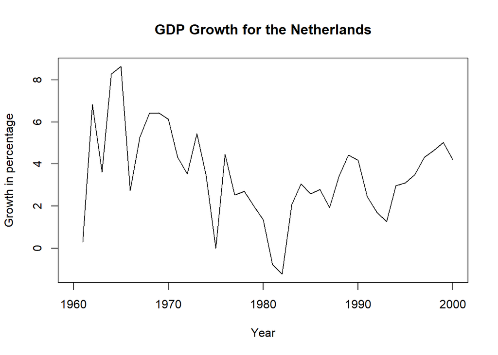

GDP growth in the Netherlands

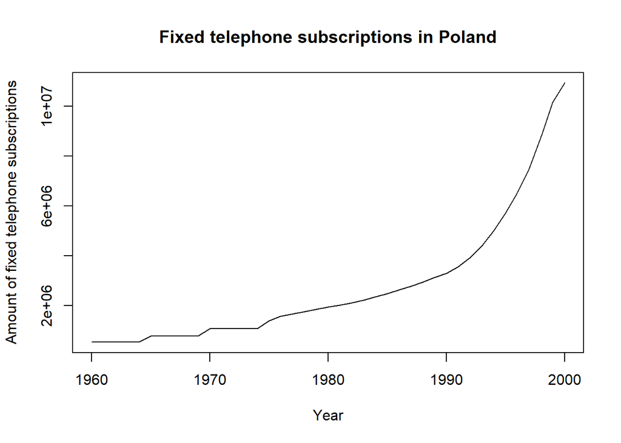

Telephone subscriptions in Poland

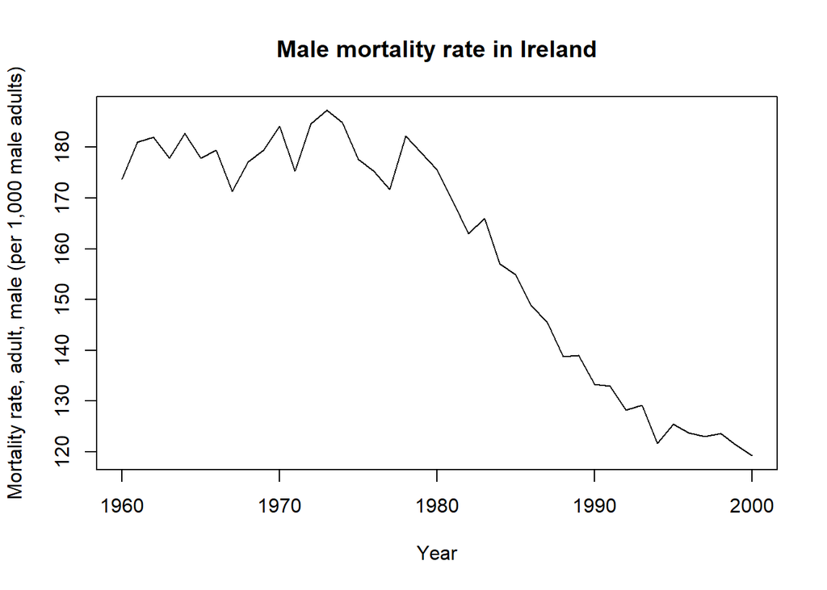

Mortality rate of males in Ireland

The oldest data points stem from 1960, from 1960 onwards European nations have seen quite a number of changes. Some nations within the dataset did not exist in their current condition across all of the years existent in the dataset, Germany for example only exists as Germany whereas for most of the time period represented in the dataset Germany was actually two countries (West Germany and East Germany). This could mean that for some nations the data itself is not completely accurate as the numbers existent in the dataset are a sum of the numbers for both nations. This might skew the data and results. This for example could show up as Germany being an immigration destination/source for many former Soviet nations and Western European nations both. Whereas in reality, East Germany was the immigration destination for Soviet nations and West Germany the immigration location for Western European nations. This will need to be taken into account and any findings regarding these aggregated nations will have to back up by literature research.

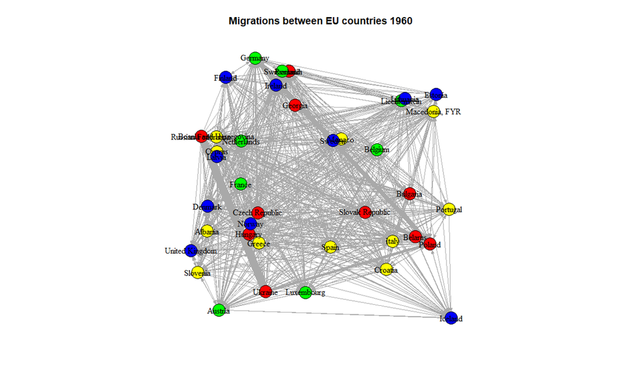

# Research Rationale

The stress centrality measure in combination with the CUG tests helps to find an answer on whether Austria is a central country in Europe’s migrant streams or not. The stress centrality measure fits this purpose because it considers incoming as well as outgoing edges. So, in that way, it simulates migrant streams through a country. Furthermore, this measure does not consider streams that end or start in Austria. Therefore, one can really see whether Austria is the central player, or in other words, the country that ‘divides’ all migrants through Europe and the country that incoming migrants use to get to other countries in Europe. The CUG tests help to see how high the average centrality in a network with a similar number of edges and vertices would ‘normally’ be, compared to the observed network. Therefore, one can argue whether Austria is a more central country than expected or not.

Looking at the stress centrality measure, one could also have chosen numerous other centrality measures. For instance, the eccentricity measure determines the maximum number of steps needed to reach any other country in the network. The country with the minimum eccentricity would be the most central country. However, this does not fit the purpose of this research since the measure only considers outgoing edges. The Shapley centrality would have been a good measure since it can also consider the weights, so the intensity of a migrant stream (Michalak et al. 2013). However, this method is currently not applied in R.

ERGM is used for the second hypothesis based on multiple reasons. Firstly, the data studied is network data as the focus of the project is on different countries and the relationships between them. Besides that, there are both network effects as well as effects coming outside of the network. Since ERGM can estimate the effect of both of these variables, it is the most suitable method for this research question. However, there are two other variations of ERGM that could address this research question. Firstly, the network can be seen as a temporal network, because it has data on five different decades. This means that another approach could be to use a TERGM, or temporal ERGM. However, as mentioned in the methods section, the attribute variables included vary over time. For example, internet access is zero in the first few decades, because it did not exist back then. Same for the number of telephone subscriptions, first this was a good indicator of technological progress, but now people only use mobiles. Because of this, TERGM cannot measure what happens over time, and what the effect of these variables is. Another option was weighted ERGM’s, since the edge attributes are weighted. However, a weighted ERGM only works well when the network is dense enough. Statistics about the network showed that the network used in this research is not that dense, meaning that weighted ERGM’s are also not appropriate. Overall, for this research regular ERGM’s seem to be the best approach.

# Results

## Model 1

The centrality of Austria was estimated by the stress centrality measure. The centrality was calculated for every country in the network, in each decade that is represented in the dataset. The results of those centrality calculations for every country can be seen in the table below.

| Country | Centrality_1960 | Centrality_1970 | Centrality_1980 | Centrality_1990 | Centrality_2000 |
| --- | --- | --- | --- | --- | --- |
| Albania | 44 | 30 | 24 | 57 | 13 |
| Austria | 162 | 147 | 79 | 84 | 97 |
| Belarus | 58 | 1 | 44 | 29 | 2 |
| Belgium | 115 | 85 | 99 | 76 | 75 |
| Bosnia and Herzegovina | 70 | 42 | 53 | 75 | 83 |
| Bulgaria | 54 | 42 | 36 | 36 | 57 |
| Croatia | 59 | 29 | 35 | 94 | 53 |
| Cyprus | 29 | 23 | 10 | 8 | 6 |
| Czech Republic | 69 | 90 | 122 | 106 | 87 |
| Denmark | 107 | 74 | 74 | 67 | 56 |
| Estonia | 4 | 10 | 4 | 32 | 79 |
| Finland | 35 | 74 | 69 | 66 | 83 |
| France | 162 | 147 | 81 | 70 | 97 |
| Georgia | 4 | 5 | 4 | 7 | 2 |
| Germany | 162 | 147 | 109 | 95 | 97 |
| Greece | 121 | 113 | 79 | 95 | 87 |
| Hungary | 142 | 94 | 79 | 76 | 67 |
| Iceland | 0 | 1 | 2 | 6 | 24 |
| Ireland | 53 | 41 | 26 | 24 | 44 |
| Italy | 162 | 147 | 109 | 76 | 97 |
| Latvia | 6 | 7 | 5 | 32 | 157 |
| Liechtenstein | 0 | 1 | 3 | 2 | 18 |
| Lithuania | 12 | 10 | 5 | 32 | 137 |
| Luxembourg | 33 | 55 | 53 | 69 | 61 |
| Macedonia, FYR | 68 | 44 | 50 | 92 | 70 |
| Monaco | 1 | 1 | 6 | 10 | 2 |
| Netherlands | 147 | 147 | 109 | 32 | 64 |
| Norway | 39 | 80 | 71 | 59 | 44 |
| Poland | 575 | 437 | 474 | 439 | 129 |
| Portugal | 21 | 21 | 48 | 33 | 6 |
| Romania | 65 | 49 | 44 | 30 | 46 |
| Russian Federation | 61 | 25 | 65 | 36 | 92 |
| Slovak Republic | 70 | 84 | 105 | 90 | 56 |
| Slovenia | 15 | 13 | 16 | 24 | 17 |
| Spain | 94 | 88 | 78 | 41 | 45 |
| Sweden | 127 | 118 | 109 | 56 | 97 |
| Switzerland | 147 | 147 | 109 | 95 | 97 |
| Ukraine | 57 | 32 | 145 | 154 | 92 |
| United Kingdom | 81 | 147 | 109 | 46 | 87 |

The results for Austria, compared to other countries, show that Austria was at the higher end of the most central countries in Europe in 1960 and 1970. In later decades, Austria seems to have an average stress centrality in Europe. The results from to the table are plotted below to get a better view on the (most) central countries for migrant streams in Europe. The vertex size corresponds with the stress centrality of a country (vertex). The edge width corresponds with the edge weight, i.e., the number of migrants in that decade.

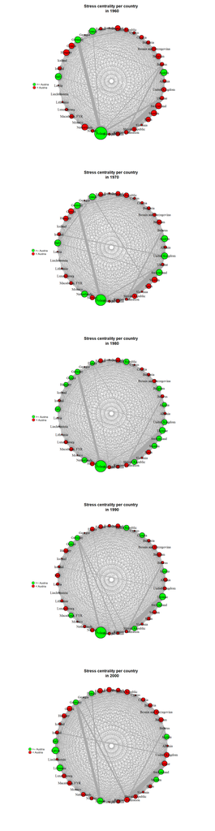

The plots show indeed that as of 1980, there are more countries within Europe that are more central than Austria regarding migrant streams. Poland seems to have the highest stress centrality in all decades except for 2000. In that decade, the differences are not that clear. In every decade, Poland has clear links with Germany (and France) and with Ukraine (and Belarus). That shows that Poland acts as a central player in the migrant stream from east to west or west to east. For Austria, those links are not that clear from the plot. The only clear link is the one with Germany but that doesn’t show centrality of Austria. The migration routes that were shown by Guggenheim (2019), cannot be seen in these observations. However, looking at the color distributions of all plots, Austria is always a country that has a higher centrality than many other countries in Europe. All in all, the plots give an indication that Austria is not the country with the highest stress centrality in Europe, but does not belong to the lower end either.

However, the plots do not give a statistically decisive judgement about the significance of Austria’s centrality. To get a better view of on that, the CUG tests are used. For each decade, the stress centrality of Austria is compared with the average expected centrality for a network with the same number of vertices and edges. Each CUG test has simulated 2000 similar networks. The average stress centrality was stored for every simulation. The empirical results can be seen below for every decade, where the simulations are represented by the density plot and the stress centrality of Austria is represented by the dashed line.

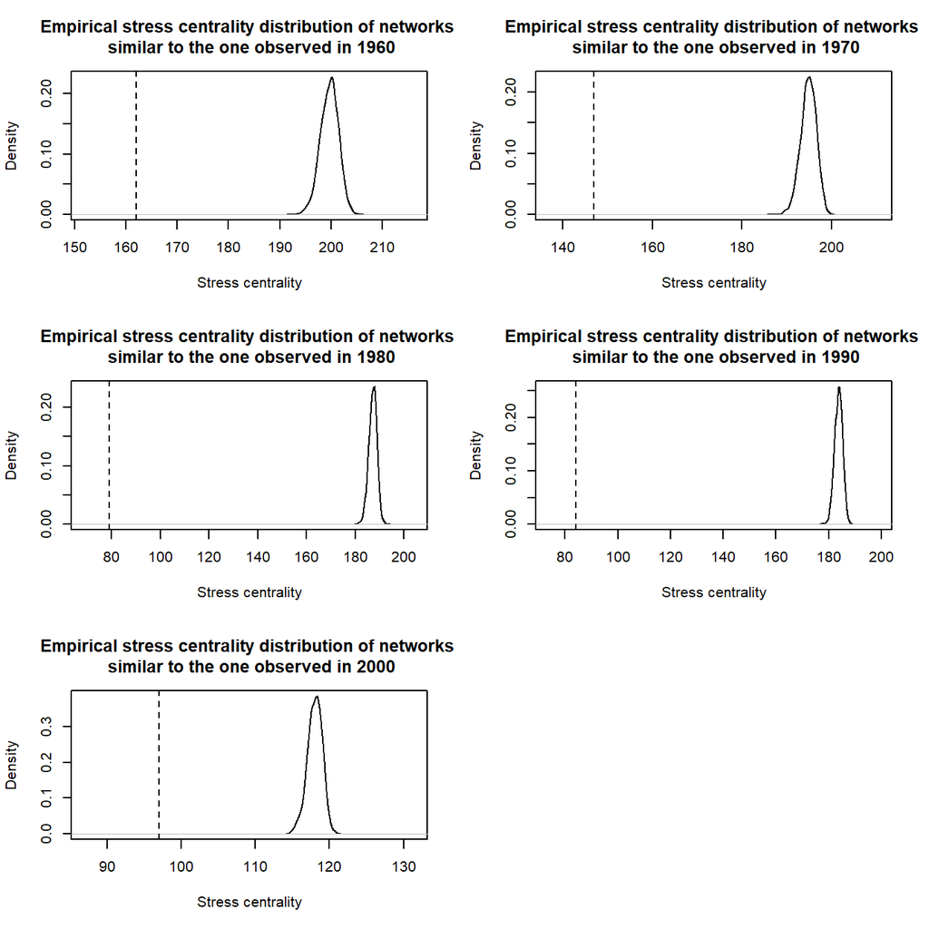

In every decade, the stress centrality of Austria seems to be exceptionally lower than networks with a similar number of vertices and directed edges. To quantify how exceptional this difference is, the proportion of stress centralities that are higher than the stress centrality of Austria were calculated for every decade. The results can be seen below.

| Year | Proportion of centralities higher than Austria |
| --- | --- |
| 1960 | 1 |
| 1970 | 1 |
| 1980 | 1 |
| 1990 | 1 |
| 2000 | 1 |

So, 100% of all networks with the same number of vertices and directed edges have a higher stress centrality than Austria has, in every decade that has been analyzed. With that, it can be said that the stress centrality of Austria is statistically significantly lower than what would have been expected for a network with this number of vertices and directed edges.

Hypothesis 1 predicted that Austria has a high centrality in the social network of Europe’s migration. The results do not support this hypothesis. Therefore, this hypothesis is rejected. Whereas Austria belongs to the higher end of the centralities of European countries, considering the stress centrality plots, the number is expected to be higher for a network that is similar to the European migrant network.

## ERGM

As mentioned in the method section of this paper, five different ERGM models have been created to be able to answer the second hypothesis, one model for every decennium in the data. For every model, the appropriate endogenous and exogenous variables have been added. To give an example, in the 1960’s mobile phones and the internet did not exist, so here the amount of telephone subscriptions is more appropriate as a measure for technological progress. A couple of different steps have been taken to get to the final model, starting with selecting these endogenous and exogenous variables. For the endogenous variables, the choice to include all of them immediately was made, since the theoretical framework showed that all these variables could have an influence on migration. However, in the first model, the measure `nodecov` was used for these exogenous variables. After trying, it appeared that this was not the most appropriate measure, and it was replaced with `dyadcov`. For the endogenous variables, `gwesp` was first used, based on the idea that there were triangles in the data. However after careful consideration, the conclusion was made that there was no theoretical proof as to why this would be true. Because of that, the measure was removed and replaced with `mutual`. After some discussion, it appeared that `asymmetric` would actually be a more appropriate measure. The goal of asymmetry is capture the fact that if a lot of people move from country A to country B, people are not likely to move from B to A. After all these variables have been selected, the MCMC specifications were added. The first attempt used 1000 samples, a burn-in of 500 and 10 iterations. However, the laptops used in this research were not able to handle this much data, and after three days and nights, only 4 iterations were complete. After this, it was decided to reduce the amount of samples and iterations, to 500 samples, 250 burn-in and 4 iterations. However, after another day and night, this model got stuck around 3 iterations. Because of this, an even smaller sample size and number of iterations have been chosen, namely 100 samples, a burn-in of 50 and 2 iterations. Some models were not able too run because the sample size was too small, so for these models the sample size was set higher. With these specifications, all the models were able to run, however the GOF will likely not be good. This will be discussed further on in this section, as well as in the limitation section of this paper. The summary of these five final models can be found below.

|  | Model 1 |
| --- | --- |
| edges | 1.21 *** |
|  | (0.09) |
| asymmetric | 0.07 |
|  | (0.09) |
| dyadcov.mortality_rate_female_df_1960.mutual | -0.05 *** |
|  | (0.00) |
| dyadcov.mortality_rate_female_df_1960.utri | -0.09 *** |
|  | (0.00) |
| dyadcov.mortality_rate_female_df_1960.ltri | -0.00 *** |
|  | (0.00) |
| dyadcov.life_expectancy__df_1960.mutual | -0.31 *** |
|  | (0.01) |
| dyadcov.life_expectancy__df_1960.utri | -0.45 *** |
|  | (0.01) |
| dyadcov.life_expectancy__df_1960.ltri | 0.01 ** |
|  | (0.01) |
| dyadcov.telephone_subscriptions_df_1960.mutual | -0.00 *** |
|  | (0.00) |
| dyadcov.telephone_subscriptions_df_1960.utri | -0.00 *** |
|  | (0.00) |
| dyadcov.telephone_subscriptions_df_1960.ltri | -0.00 *** |
|  | (0.00) |
| dyadcov.electrical_power_df_1960.mutual | -0.00 *** |
|  | (0.00) |
| dyadcov.electrical_power_df_1960.utri | -0.00 *** |
|  | (0.00) |
| dyadcov.electrical_power_df_1960.ltri | -0.00 *** |
|  | (0.00) |
| AIC | -848225.55 |
| BIC | -848151.33 |
| Log Likelihood | 424126.77 |

|  | Model 1 |
| --- | --- |
| edges | 1.17 *** |
|  | (0.10) |
| asymmetric | -0.19 |
|  | (0.12) |
| dyadcov.mortality_rate_female_df_1970.mutual | -0.02 *** |
|  | (0.00) |
| dyadcov.mortality_rate_female_df_1970.utri | -0.06 *** |
|  | (0.00) |
| dyadcov.mortality_rate_female_df_1970.ltri | 0.00 *** |
|  | (0.00) |
| dyadcov.life_expectancy__df_1970.mutual | -0.26 *** |
|  | (0.01) |
| dyadcov.life_expectancy__df_1970.utri | -0.35 *** |
|  | (0.01) |
| dyadcov.life_expectancy__df_1970.ltri | -0.09 *** |
|  | (0.01) |
| dyadcov.telephone_subscriptions_df_1970.mutual | 0.00 |
|  | (0.00) |
| dyadcov.telephone_subscriptions_df_1970.utri | -0.00 * |
|  | (0.00) |
| dyadcov.telephone_subscriptions_df_1970.ltri | 0.00 ** |
|  | (0.00) |
| dyadcov.electrical_power_df_1970.mutual | -0.00 ** |
|  | (0.00) |
| dyadcov.electrical_power_df_1970.utri | 0.00 *** |
|  | (0.00) |
| dyadcov.electrical_power_df_1970.ltri | -0.00 *** |
|  | (0.00) |
| AIC | 1089963.27 |
| BIC | 1090037.49 |
| Log Likelihood | -544967.64 |

|  | Model 1 |
| --- | --- |
| edges | 1.66 *** |
|  | (0.11) |
| asymmetric | 0.38 ** |
|  | (0.13) |
| dyadcov.life_expectancy__df_1980.mutual | -0.33 *** |
|  | (0.00) |
| dyadcov.life_expectancy__df_1980.utri | -0.27 *** |
|  | (0.00) |
| dyadcov.life_expectancy__df_1980.ltri | -0.16 *** |
|  | (0.00) |
| dyadcov.mortality_rate_female_df_1980.mutual | -0.01 *** |
|  | (0.00) |
| dyadcov.mortality_rate_female_df_1980.utri | -0.01 *** |
|  | (0.00) |
| dyadcov.mortality_rate_female_df_1980.ltri | 0.01 *** |
|  | (0.00) |
| dyadcov.electrical_power_df_1980.mutual | -0.00 *** |
|  | (0.00) |
| dyadcov.electrical_power_df_1980.utri | 0.00 *** |
|  | (0.00) |
| dyadcov.electrical_power_df_1980.ltri | -0.00 *** |
|  | (0.00) |
| dyadcov.mobile_subscriptions_df_1980.mutual | 0.00 *** |
|  | (0.00) |
| dyadcov.mobile_subscriptions_df_1980.utri | -0.00 ** |
|  | (0.00) |
| dyadcov.mobile_subscriptions_df_1980.ltri | -0.00 *** |
|  | (0.00) |
| dyadcov.telephone_subscriptions_df_1980.mutual | 0.00 * |
|  | (0.00) |
| dyadcov.telephone_subscriptions_df_1980.utri | -0.00 *** |
|  | (0.00) |
| dyadcov.telephone_subscriptions_df_1980.ltri | 0.00 *** |
|  | (0.00) |
| AIC | 637760.29 |
| BIC | 637850.40 |
| Log Likelihood | -318863.14 |

|  | Model 1 |
| --- | --- |
| edges | 1.62 *** |
|  | (0.11) |
| asymmetric | 0.33 * |
|  | (0.13) |
| dyadcov.life_expectancy__df_1990.mutual | -0.07 *** |
|  | (0.01) |
| dyadcov.life_expectancy__df_1990.utri | -0.06 *** |
|  | (0.00) |
| dyadcov.life_expectancy__df_1990.ltri | 0.08 *** |
|  | (0.01) |
| dyadcov.mortality_rate_female_df_1990.mutual | 0.01 *** |
|  | (0.00) |
| dyadcov.mortality_rate_female_df_1990.utri | 0.01 *** |
|  | (0.00) |
| dyadcov.mortality_rate_female_df_1990.ltri | 0.02 *** |
|  | (0.00) |
| dyadcov.mediumhightech_exports_df_1990.mutual | -0.00 *** |
|  | (0.00) |
| dyadcov.mediumhightech_exports_df_1990.utri | 0.00 |
|  | (0.00) |
| dyadcov.mediumhightech_exports_df_1990.ltri | 0.00 |
|  | (0.00) |
| dyadcov.electrical_power_df_1990.mutual | -0.00 *** |
|  | (0.00) |
| dyadcov.electrical_power_df_1990.utri | 0.00 *** |
|  | (0.00) |
| dyadcov.electrical_power_df_1990.ltri | -0.00 *** |
|  | (0.00) |
| dyadcov.mobile_subscriptions_df_1990.mutual | -0.00 * |
|  | (0.00) |
| dyadcov.mobile_subscriptions_df_1990.utri | -0.00 *** |
|  | (0.00) |
| dyadcov.mobile_subscriptions_df_1990.ltri | -0.00 *** |
|  | (0.00) |
| AIC | 368759.94 |
| BIC | 368850.06 |
| Log Likelihood | -184362.97 |

[output not shown]

Both the overall hypothesis, as well as the hypotheses for the endogenous and exogenous variables need to be answered. In the model, the three different dyad states are displayed, namely mutual, upper-triangular asymmetric, and lower-triangular asymmetric dyads.

For our hypotheses, we are only interested in people moving from the row country to the column country, which is captured with the lower-triangular asymmetric dyads. The first hypotheses was that “people will move to countries with a lower mortality rate, compared to the country they are currently living in”. For this we found a positive and significant effect for three of our models, and the others were negative and significant as well as non-significant. Because of this, this hypothesis is partially proven.

The second hypothesis was that “people will move to countries with a higher life expectancy for women, compared to the country they are currently living in”. Two models show a positive and significant effect and two show a negative and significant effect, the last model had a non-significant effect. With this information, this hypothesis cannot be proven.

Then the final hypothesis was “if people move from country A to country B, it is not likely that people move from country B to country A”. This was measured with asymmetry, for which four out of five results were positive. However, only two were significant, both of which captured a positive effect. Because of this, the hypothesis has been partially proven.

For the overall hypothesis, the coefficient and its significance need to be compared for all five models. When looking at the results, it does not appear that technological process becomes more important with time. The coefficients of the variables are all very close to each other, and there does not appear to be a change in significance. Because of this, the overall hypothesis cannot be proven.

Besides these results, it is also important to have a look at the diagnostics of the model. This will show us whether the models used were correct and appropriate for this analysis. Firstly, the MCMC diagnostics will be displayed, after that the GOF diagnostics. For the MCMC diagnostics, the focus will be on the first four plots, the trace of edges, the density of the edges, the trace of asymmetric and the density of asymmetric. To save space, the full MCMC diagnostics will be displayed for the first model only. For the other models, only the first four plots will be displayed.

[output not shown]

[output cut: 738 more lines]

[output not shown]

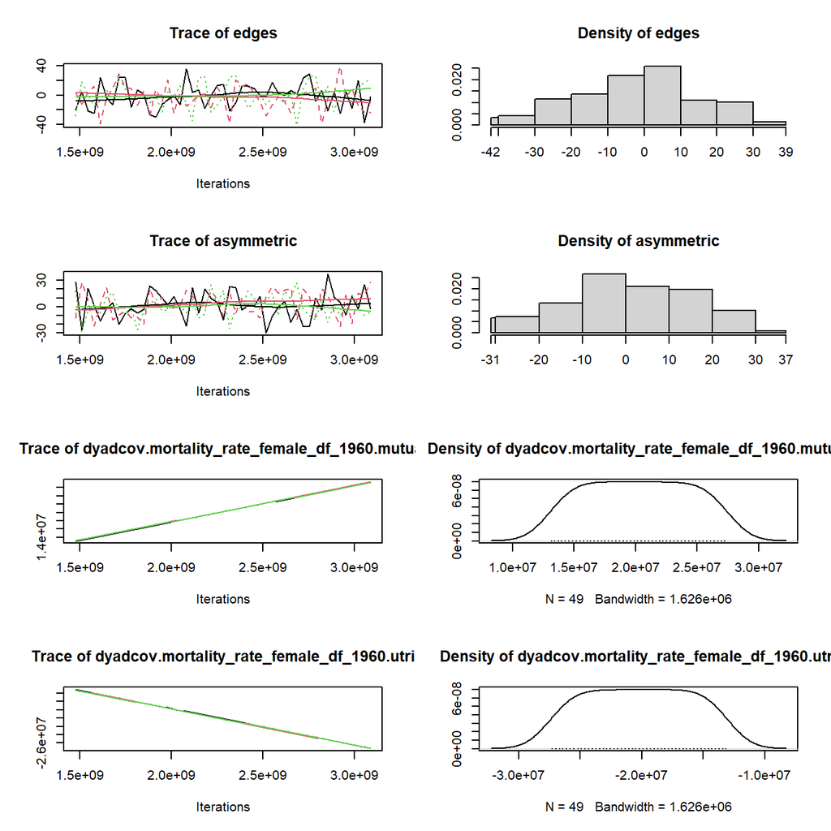

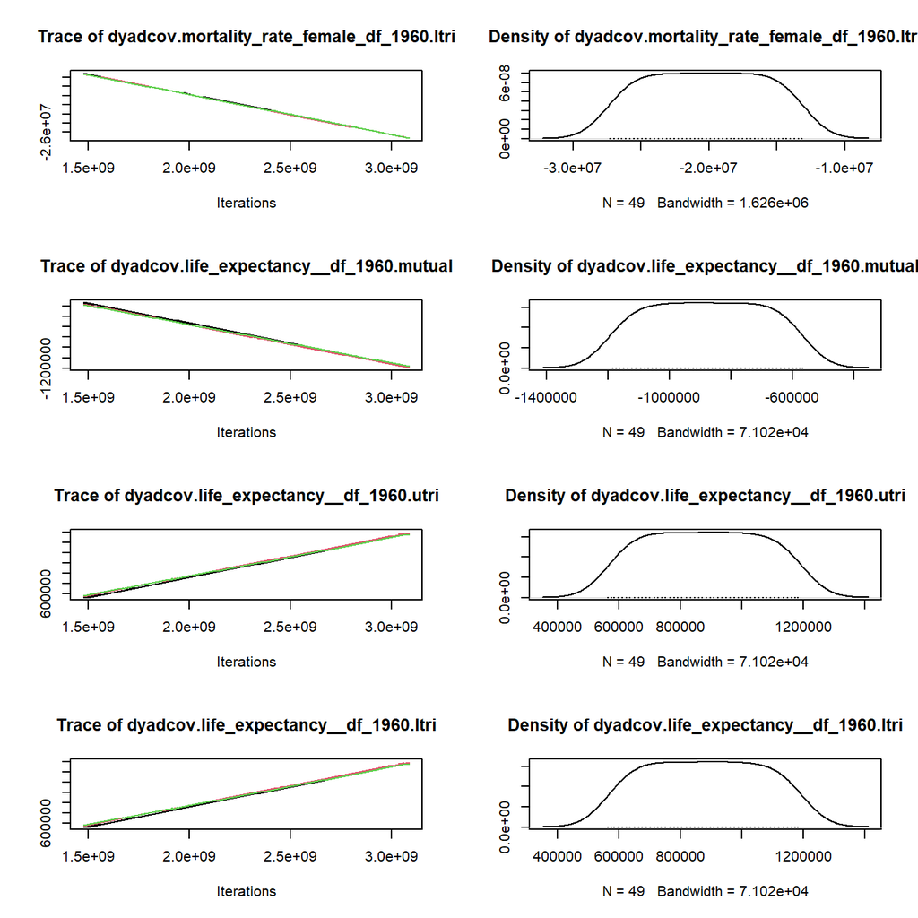

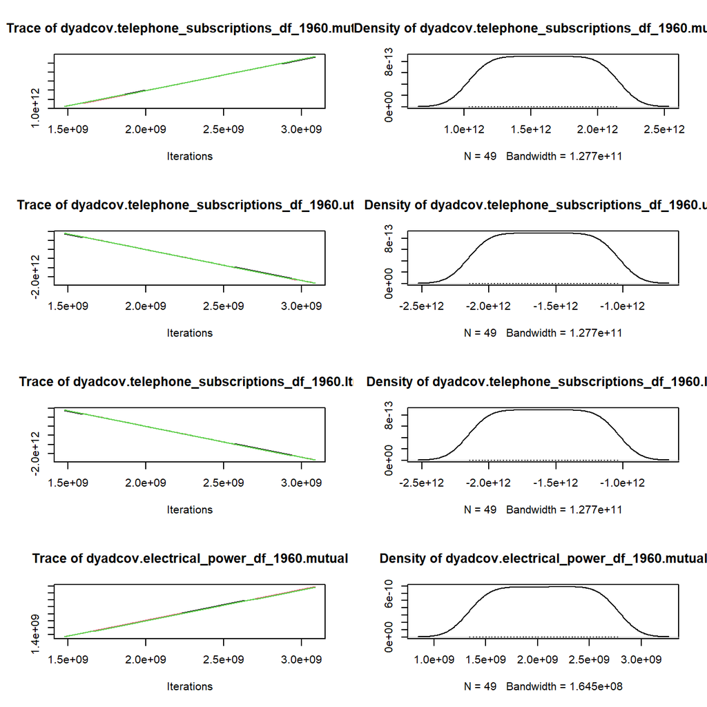

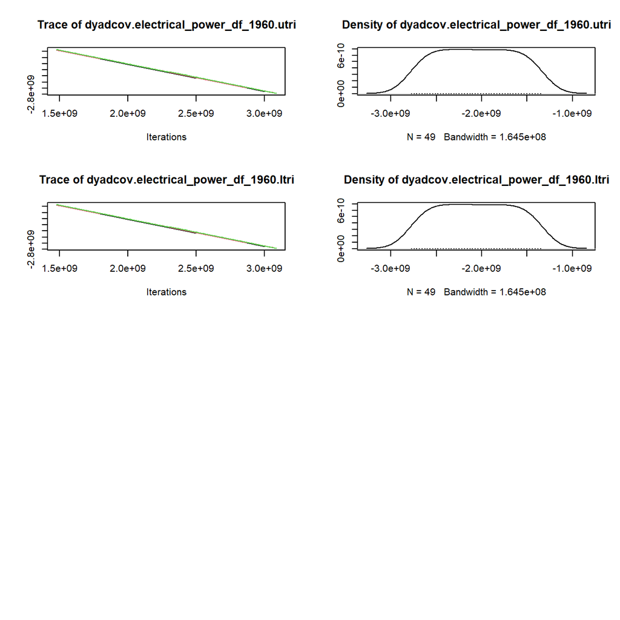

[output not shown]

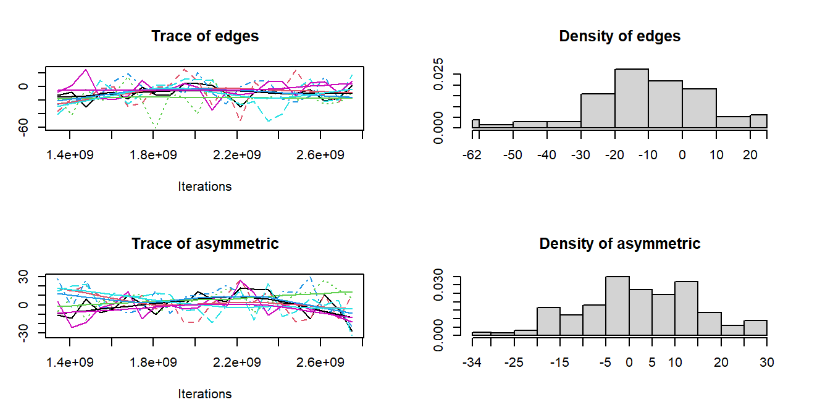

MCMC diagnostics: model 1970

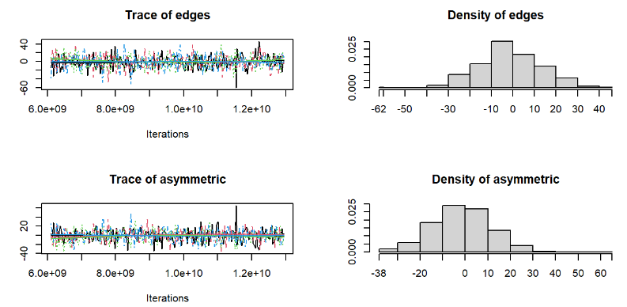

MCMC diagnostics: model 1980

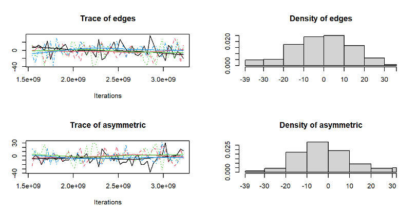

MCMC diagnostics: model 1990

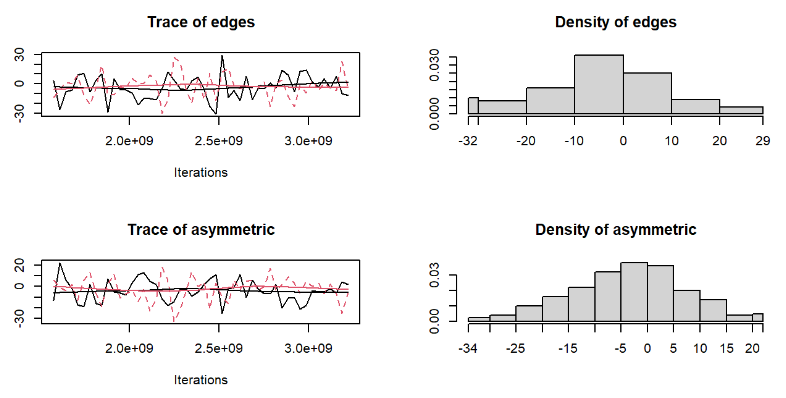

MCMC diagnostics: model 2000

The goodness of fit can also be plotted for all the models, which can be seen below.

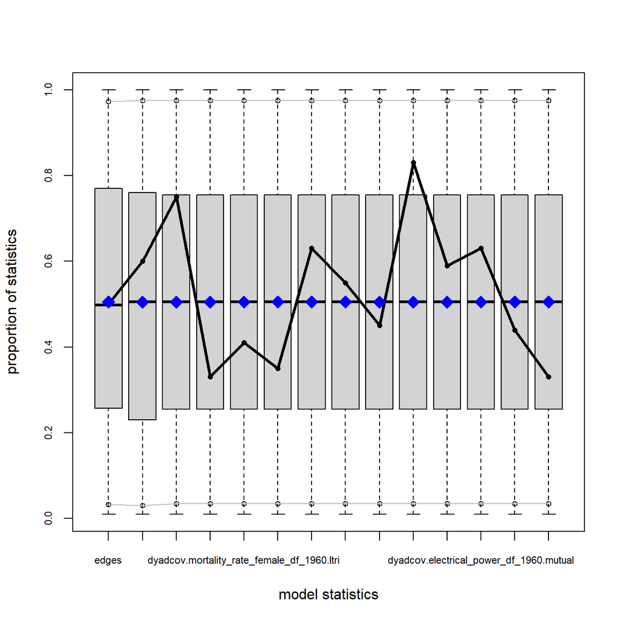

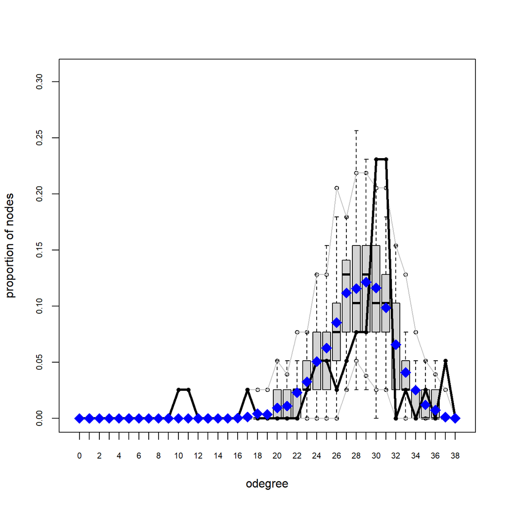

[output not shown]

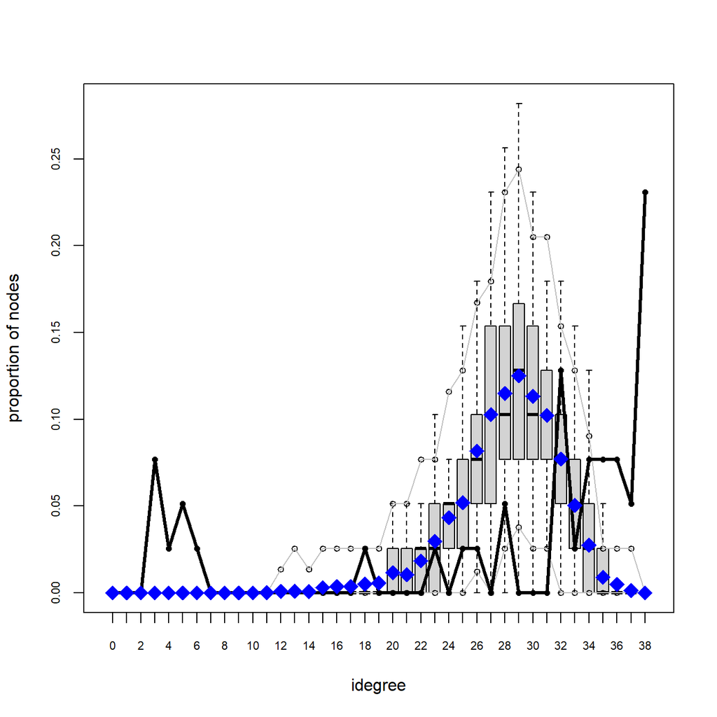

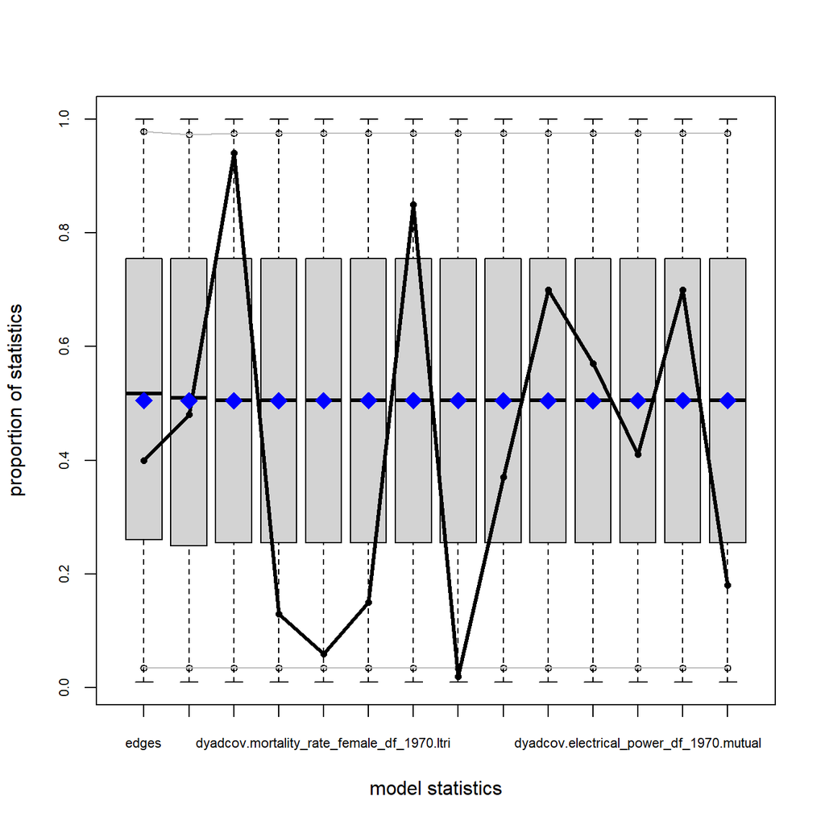

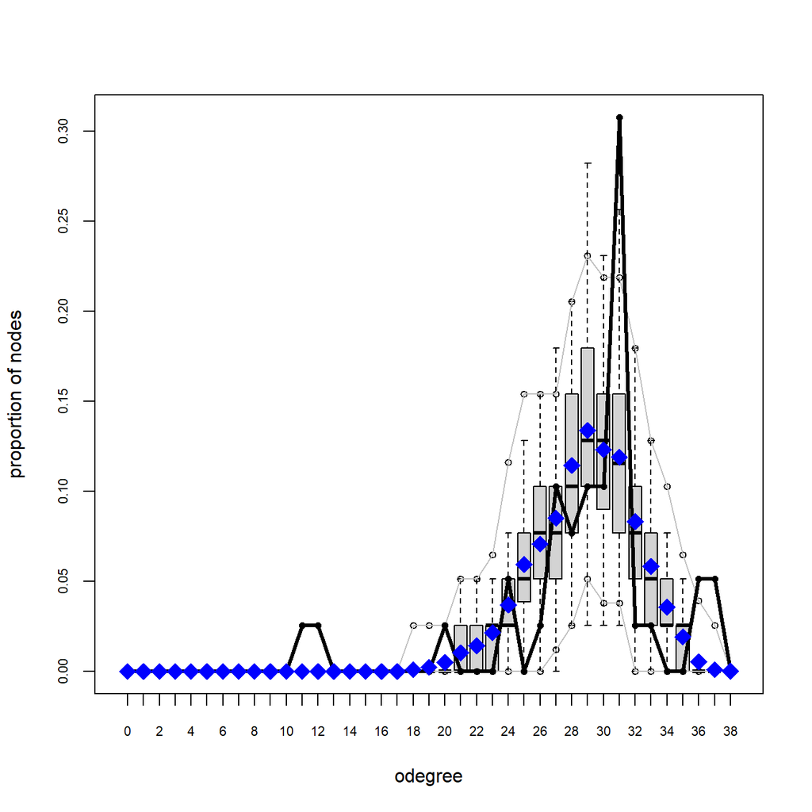

[output not shown]

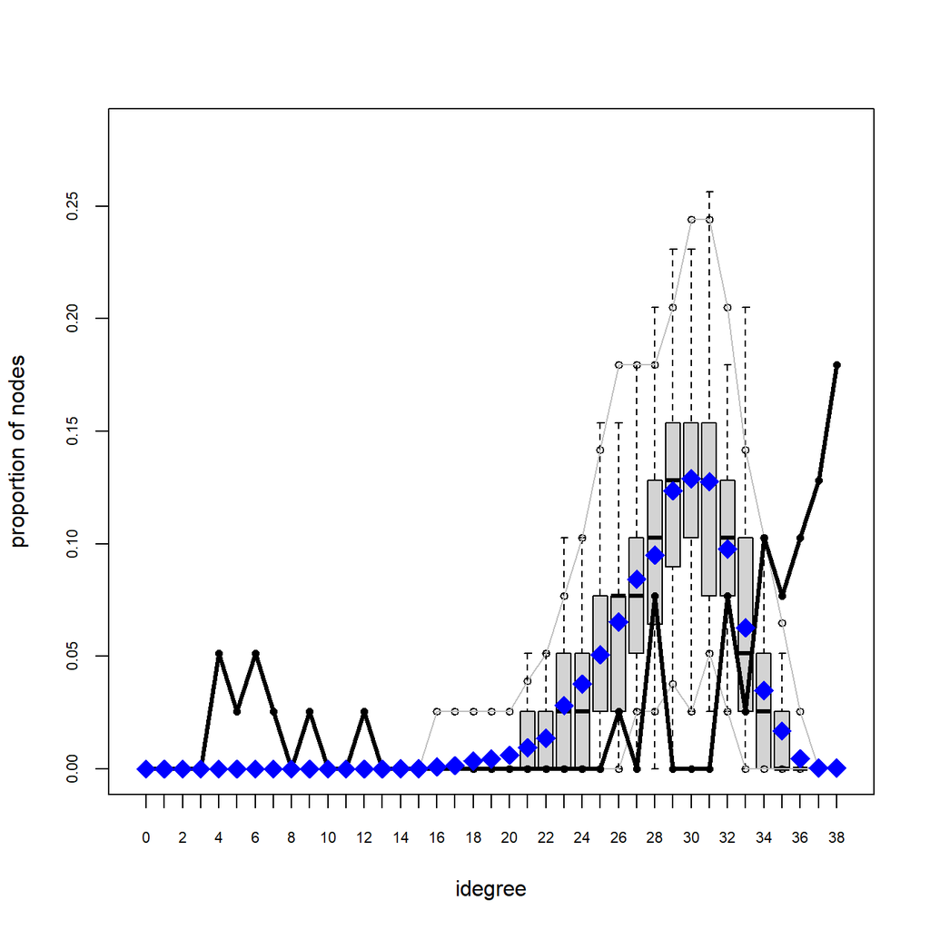

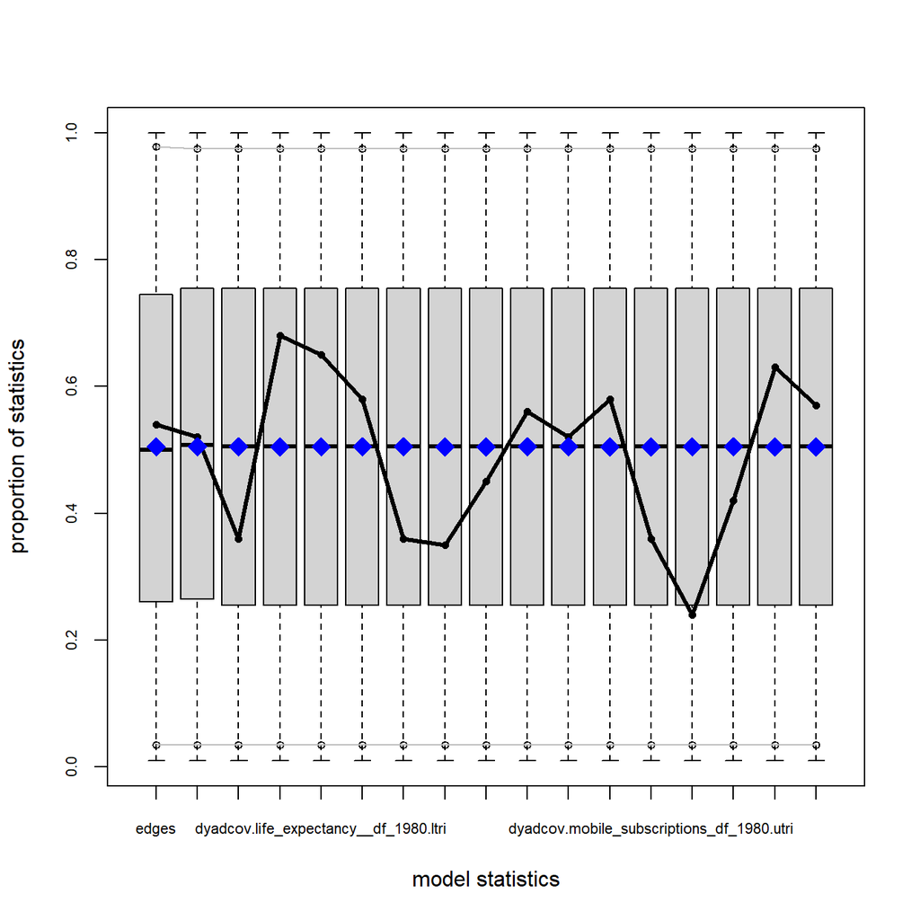

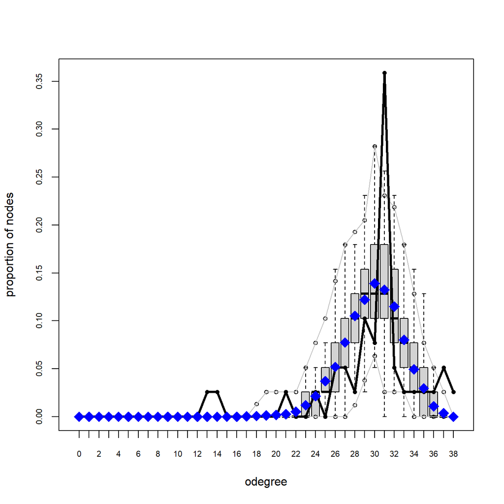

[output not shown]

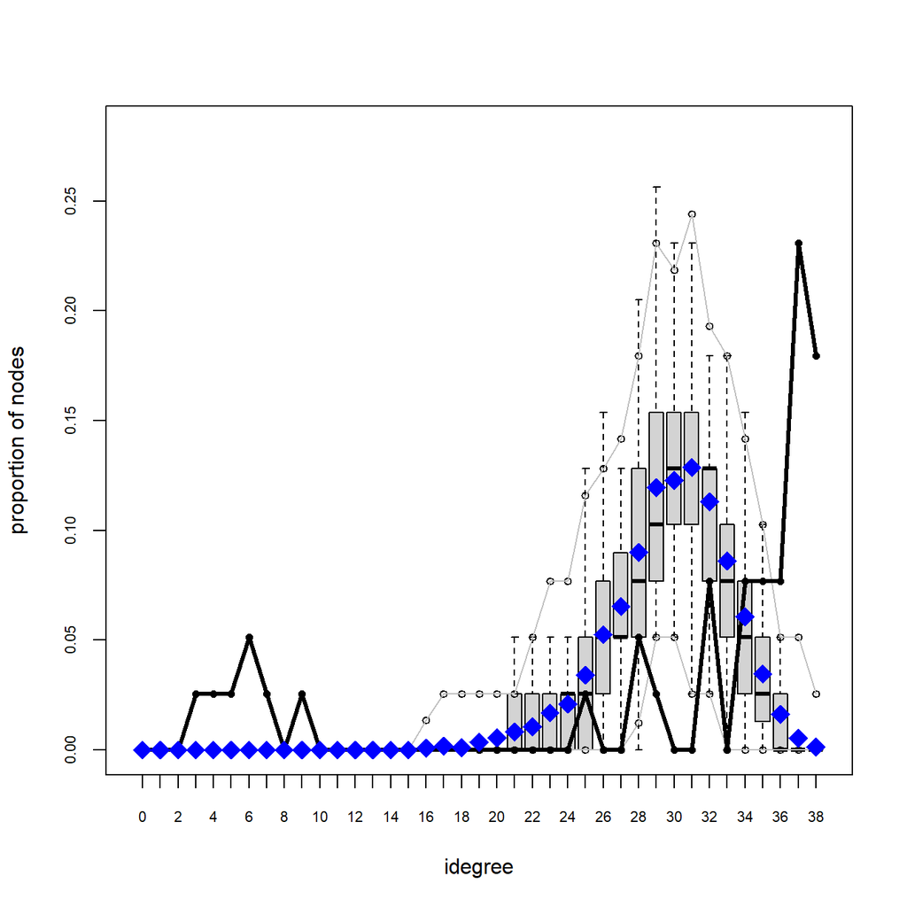

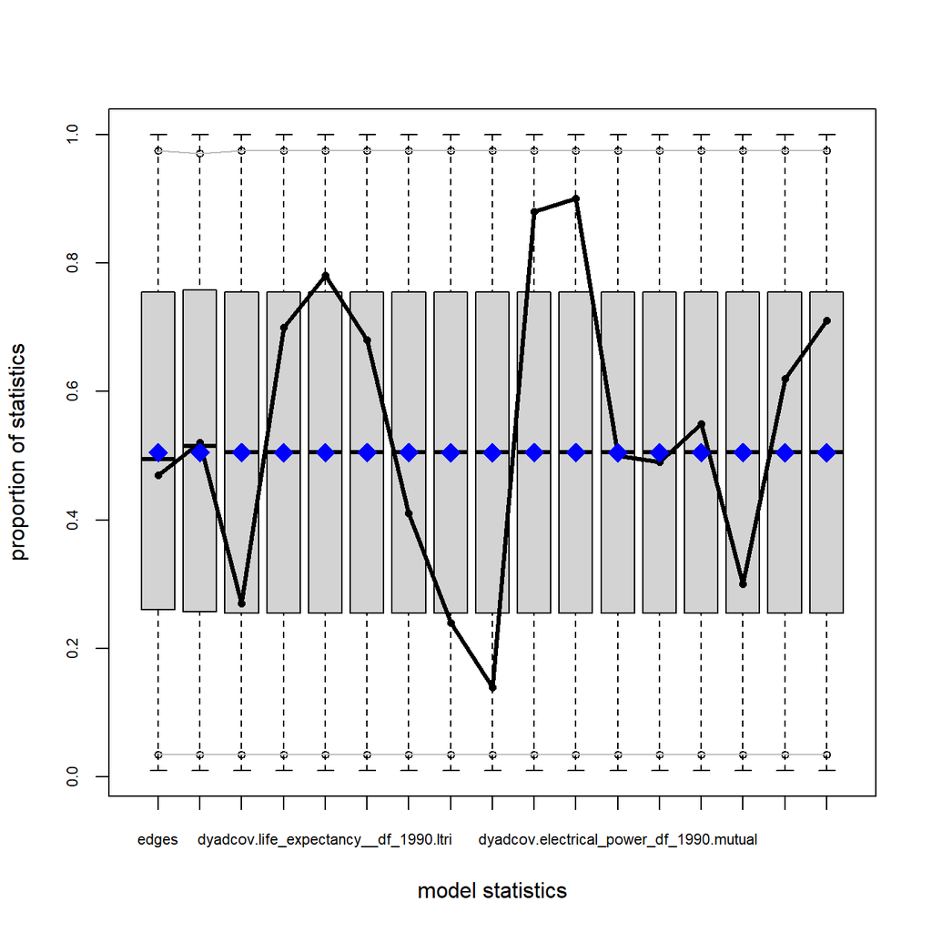

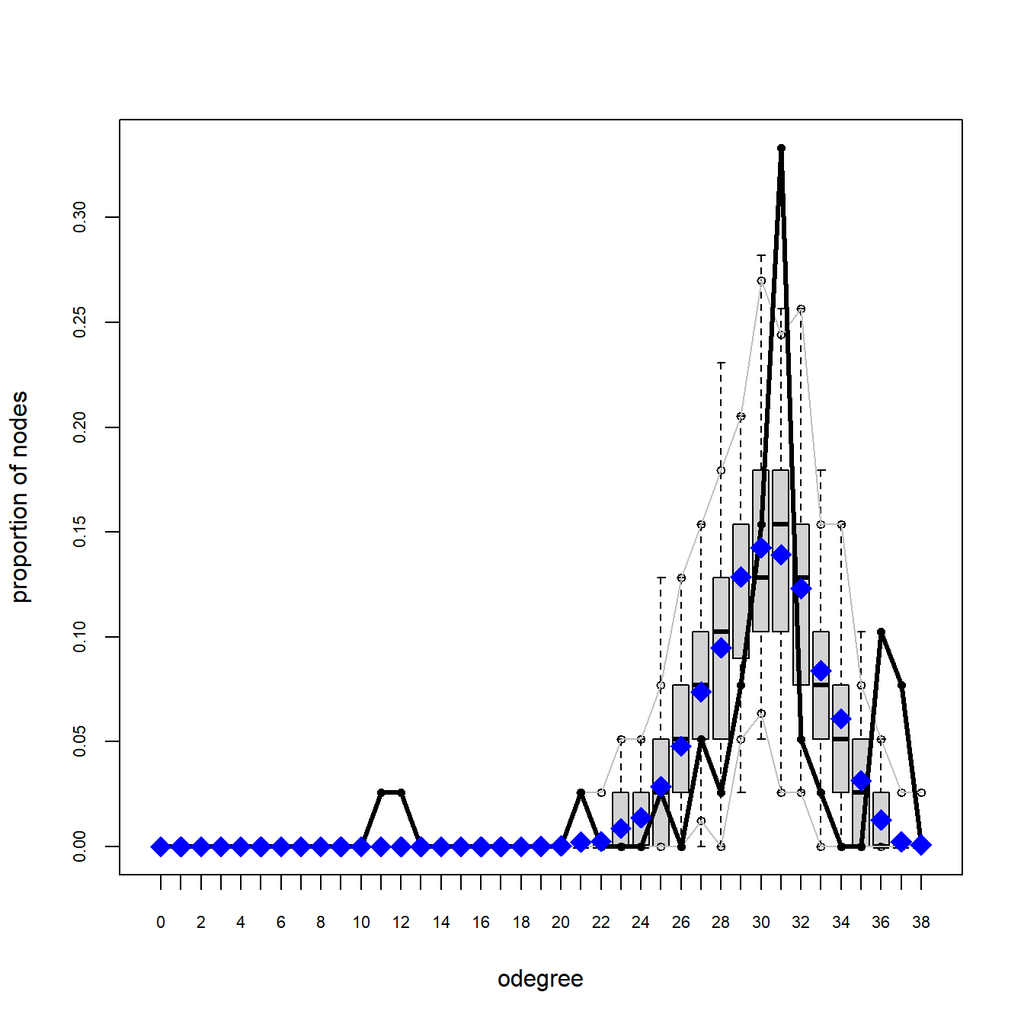

[output not shown]

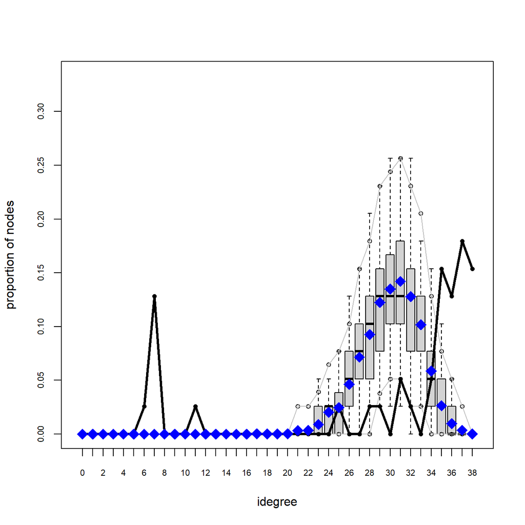

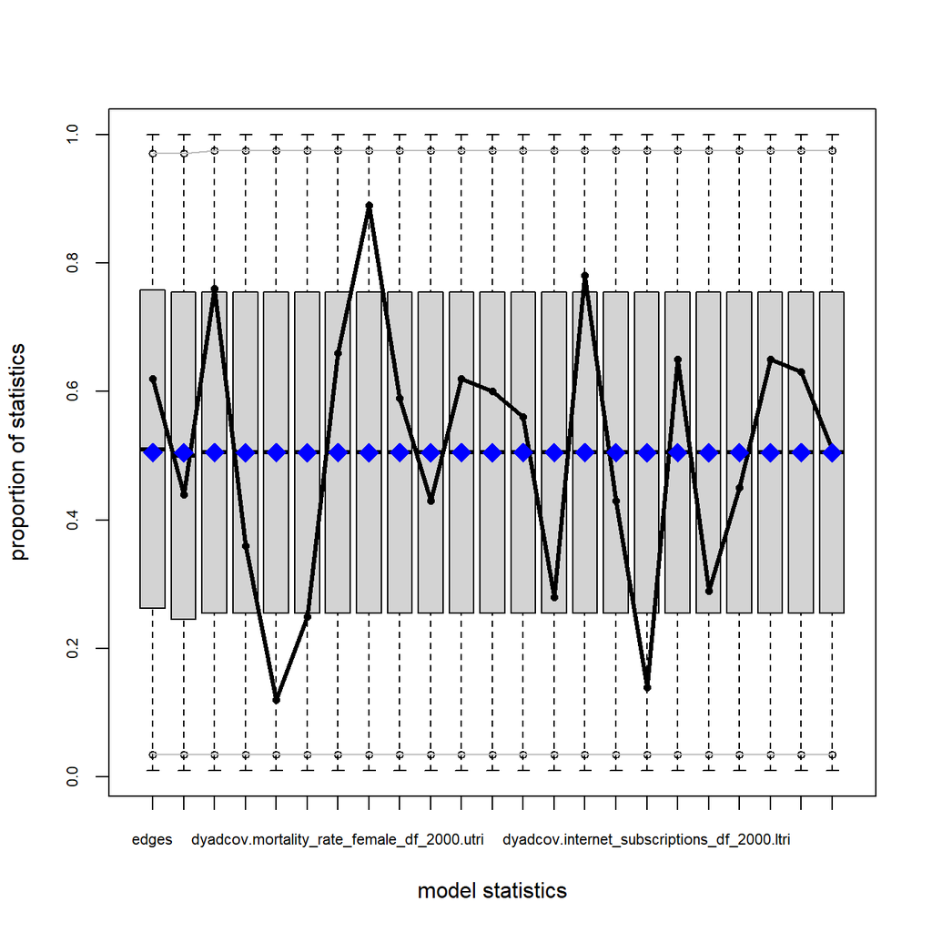

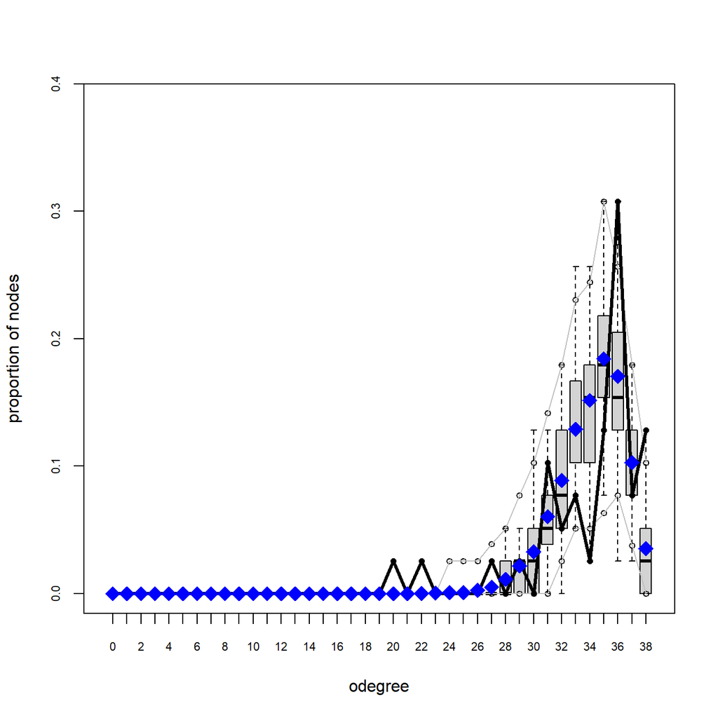

[output not shown]

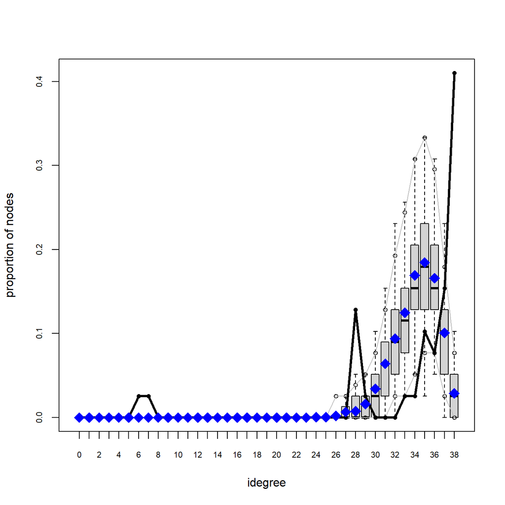

# Conclusion

People choose to immigrate for a variety of different reasons, in this paper the effect of technological development on European immigration was studied. The following research questions were formulated to help with this research:

Research Question 1: What effect does a central geographical location have on the centrality within Europe’s migration network?

Research Question 2: What effect did the global technological advances have on the migration rates between European countries over time?

The stress centrality of Austria as the most central European was taken to discern if the central geographical location had any significant effect on the stress level within the network. A CUG test was performed which showed that Austria had a lower than expected stress level for a network of this structure. As such it can be concluded that a central geographical location has no correlation with a higher stress centrality.

When looking at the overall results of the different hypotheses per decade and comparing the significances and coefficients per decade, it did not appear that the technological processes became more important per decade. The MCMC diagnostics were all centered around zero. However, because of the low amount of samples and iterations the plots was not very ‘fuzzy’. The GOF showed that our simulated networks did not represent our actual network and as such the models were found not usable. Because of this we could not use the results that we found to answer our research question. Possible stakeholders who could benefit from these findings are politicians and members of the European Parliament (EMP) who are trying to understand the migration patterns and underlying reasons of why people move between European nations to a greater extent.

Since the models were not run using a proper sample size, burning and iterations, the results (MCMC diagnostics and GOF) might differ a lot when running them using a higher number. Due to hardware and time constraints this was not possible. This could be tackled by utilizing different optimization routines like stochastic approximation or by using more powerful hardware that is given more time to simulate the networks. At this moment we used non-ideal variables to estimate technological development. Future research could take into account other variables (e.g. amount of people employed in tech sector) to see if this better captures the effect of technological development.

# References

Ambrosini, Maurizio. 2016. *Europe. No Migrant’s Land?* ISPI.

Berlemann, Michael, and Max Friedrich Steinhardt. 2017. “Climate Change, Natural Disasters, and Migration—a Survey of the Empirical Evidence.” *CESifo Economic Studies* 63 (4): 353–85. https://doi.org/10.1093/cesifo/ifx019.

Czaika, Mathias. 2015. “Migration and Economic Prospects.” *Journal of Ethnic and Migration Studies* 41 (1): 58–82. https://doi.org/10.1080/1369183x.2014.924848.

DaVanzo, Julie. 1978. “Does Unemployment Affect Migration? Evidence from Micro Data.” *The Review of Economics and Statistics*, 504–14. https://doi.org/10.2307/1924242.

Davenport, Christina, Will Moore, and Steven Poe. 2003. “Sometimes You Just Have to Leave: Domestic Threats and Forced Migration, 1964-1989.” *International Interactions* 29 (1): 27–55. https://doi.org/10.1080/03050620304597.

Drabo, Alassane, and Linguère Mously Mbaye. 2015. “Natural Disasters, Migration and Education: An Empirical Analysis in Developing Countries.” *Environment and Development Economics* 20 (6): 767–96. https://doi.org/10.1017/s1355770x14000606.

Dustmann, Christian, and Tommaso Frattini. 2011. “Immigration: The European Experience.” *Centro Studi Luca d’Agliano Development Studies Working Paper*, no. 326. https://doi.org/10.2139/ssrn.2023575.

European Parliament. 2020. “Exploring Migration Causes – Why People Migrate.” European Parliament News. October 30, 2020. https://www.europarl.europa.eu/news/en/headlines/world/20200624STO81906/exploring-migration-causes-why-people-migrate.

Fassio, Claudio, Fabio Montobbio, and Alessandra Venturini. 2019. “Skilled Migration and Innovation in European Industries.” *Research Policy* 48 (3): 706–18. https://doi.org/10.1016/j.respol.2018.11.002.

Frontex. n.d. “Western Mediterranean Route.” https://frontex.europa.eu/we-know/migratory-routes/western-mediterranean-route/.

Guggenheim, Lana B. 2019. “What to Expect from the 6th South EU Summit?” South EU Summit. June 11, 2019. https://southeusummit.com/europe/what-to-expect-from-the-6th-south-eu-summit/.

Hillmann, Fecilitas, Maurizio Ambrosini, Martin Bak Jørgensen, Tesseltje De Lange, Howard Duncan, Mariella Falkenhain, Chin Lin Pang, et al. 2020. In *Technological Developments, Migration and the Future of Work*. Berlin, Germany: International Metropolis Conference.

Kontuly, Thomas, and Ken R Smith. 1995. “Culture as a Determinant of Reasons for Migration.” *The Social Science Journal* 32 (2): 179–93. https://doi.org/10.1016/0362-3319(95)90004-7.

Lam, Kit-Chun. 2002. “Interaction Between Economic and Political Factors in the Migration Decision.” *Journal of Comparative Economics* 30 (3): 488–504. https://doi.org/10.1006/jcec.2002.1783.

McAuliffe, Marie, and Binod Khadria. 2019. “World Migration Report 2020.” 1561-5502. Geneva, Switzerland: International Organization for Migration.

Michalak, Tomasz P, Karthik V Aadithya, Piotr L Szczepanski, Balaraman Ravindran, and Nicholas R Jennings. 2013. “Efficient Computation of the Shapley Value for Game-Theoretic Network Centrality.” *Journal of Artificial Intelligence Research* 46: 607–50.

Mortensen, Dale T, and Christopher A Pissarides. 1998. “Technological Progress, Job Creation, and Job Destruction.” *Review of Economic Dynamics* 1 (4): 733–53. https://doi.org/10.1006/redy.1998.0030.

OECD. 2014. “Is Migration Good for the Economy?” https://www.oecd.org/migration/OECD.

The World Bank Group. 2022. *World Development Indicators*. The World Bank Group. https://databank.worldbank.org/source/world-development-indicators.

Tranos, Emmanouil, Masood Gheasi, and Peter Nijkamp. 2015. “International Migration: A Global Complex Network.” *Environment and Planning B: Planning and Design* 42 (1): 4–22. https://doi.org/10.1068/b39042.

# Appendix

## Appendix 1: Data exploration

```r
library("writexl")
library("dplyr")
library("ggplot2")
library("readxl")

# Migration data
migration_data <- read_excel('../migration_data.xlsx')

# Rename additional attributes
drop <- c("Time Code", "Country Code")
info_data = my_data[,!(names(my_data) %in% drop)]
info_data <- setNames(info_data, c("Year", "Country", "Airtransport", "Energy", "Cereal", "Electricpower", "Employers", "Telephonesubscriptions", "GDP", "Internet", "Lifeexpectancy", "Techexports", "Techmanufacturing", "Mobilesubscriptions", "Mortalityfemale", "Mortalitymale", "Drinkingwater", "Journalarticles", "Internetservers", "Survival65female", "Survival65male", "Technicians"))

# Filters for plots
netherlands <- info_data %>% filter(Country == 'Netherlands')
poland <- info_data %>% filter(Country == 'Poland')
ireland <- info_data %>% filter(Country == 'Ireland')
```

```r
plot(netherlands$Year, netherlands$GDP, type='l', main='GDP Growth for the Netherlands', xlab='Year', ylab='Growth in percentage')
```

```r
plot(poland$Year, poland$Telephonesubscriptions, type='l', main='Fixed telephone subscriptions in Poland', xlab='Year', ylab='Amount of fixed telephone subscriptions')
```

```r
plot(ireland$Year, ireland$Mortalitymale, type='l', main='Male mortality rate in Ireland', xlab='Year', ylab='Mortality rate, adult, male (per 1,000 male adults)')
```

Example of a plot used to explore the structure of the network

```r
load("network.rda")
```

[output not shown]

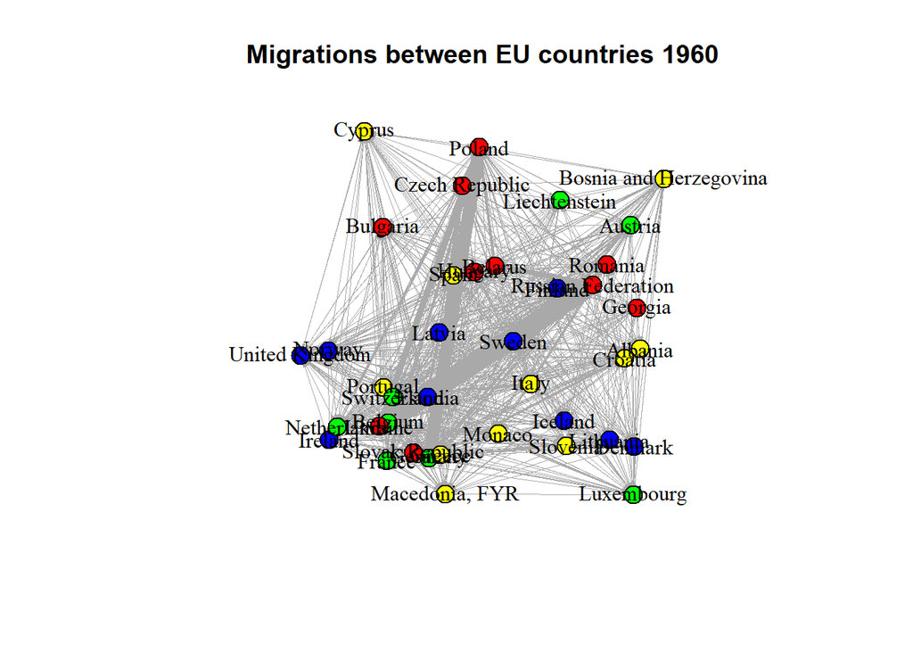

```r
plot(migration_networks[[1]],
     vertex.shape="circle",
     layout = igraph::layout_randomly,
     main= "Migrations between EU countries 1960",
     edge.width = igraph::E(migration_networks[[1]])$weight.scaled*15,
     edge.arrow.size = 0.1,
     vertex.color = igraph::V(migration_networks[[1]])$color,
     vertex.size = 10,
     vertex.label.color = 'black',
)
```

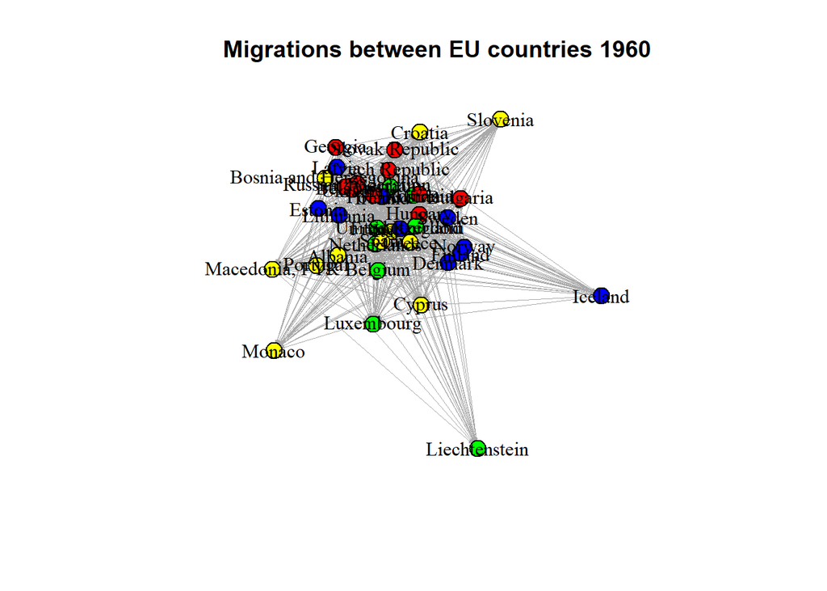

```r
plot(migration_networks[[1]],
     vertex.shape="circle",
     layout = igraph::layout.fruchterman.reingold,
     main= "Migrations between EU countries 1960",
     edge.width = igraph::E(migration_networks[[1]])$weight.scaled*15,
     edge.arrow.size = 0.1,
     vertex.color = igraph::V(migration_networks[[1]])$color,
     vertex.size = 10,
     vertex.label.color = 'black',
)
```

A summary was created for every network to get some sense of the network’s statistics

```r
snafun::g_summary(migration_networks[[1]])
```

```
## $number_of_vertices
## [1] 39
##
## $number_of_edges
## [1] 1101
##
## $density
## [1] 0.743
##
## $reciprocity
## [1] 0.741
##
## $transitivity
## [1] 0.949
##
## $mean_distance
## [1] 14743.42
##
## $number_of_isolates
## [1] 0
##
## $dyad_census
##   Mutual Asymmetric Null
## 1    408        285   48
##
## $triad_census
##   003 012 102 021D 021U 021C 111D 111U 030T 030C 201 120D 120U 120C  210  300
## 1  30 174  47  111  163  178  393  175  671    0 224 2378  361  109 1190 2935
```

```r
snafun::g_summary(migration_networks[[2]])
```

```
## $number_of_vertices
## [1] 39
##
## $number_of_edges
## [1] 1128
##
## $density
## [1] 0.761
##
## $reciprocity
## [1] 0.77
##
## $transitivity
## [1] 0.959
##
## $mean_distance
## [1] 4689.977
##
## $number_of_isolates
## [1] 0
##
## $dyad_census
##   Mutual Asymmetric Null
## 1    434        260   47
##
## $triad_census
##   003 012 102 021D 021U 021C 111D 111U 030T 030C 201 120D 120U 120C  210  300
## 1  20 186 149   45  110   97  400  104  449    0 253 2339  536   52 1225 3174
```

```r
snafun::g_summary(migration_networks[[3]])
```

```
## $number_of_vertices
## [1] 39
##
## $number_of_edges
## [1] 1160
##
## $density
## [1] 0.783
##
## $reciprocity
## [1] 0.764
##
## $transitivity
## [1] 0.974
##
## $mean_distance
## [1] 5179.822
##
## $number_of_isolates
## [1] 0
##
## $dyad_census
##   Mutual Asymmetric Null
## 1    443        274   24
##
## $triad_census
##   003 012 102 021D 021U 021C 111D 111U 030T 030C 201 120D 120U 120C  210  300
## 1   4  72  28   46   94   94  224   87  502    0 131 2588  609   48 1291 3321
```

```r
snafun::g_summary(migration_networks[[4]])
```

```
## $number_of_vertices
## [1] 39
##
## $number_of_edges
## [1] 1173
##
## $density
## [1] 0.791
##
## $reciprocity
## [1] 0.777
##
## $transitivity
## [1] 0.973
##
## $mean_distance
## [1] 2387.092
##
## $number_of_isolates
## [1] 0
##
## $dyad_census
##   Mutual Asymmetric Null
## 1    456        261   24
##
## $triad_census
##   003 012 102 021D 021U 021C 111D 111U 030T 030C 201 120D 120U 120C  210  300
## 1   1  59  42   40   13  101  288  110  344    0 131 2461  827   16 1252 3454
```

```r
snafun::g_summary(migration_networks[[5]])
```

```
## $number_of_vertices
## [1] 39
##
## $number_of_edges
## [1] 1327
##
## $density
## [1] 0.895
##
## $reciprocity
## [1] 0.892
##
## $transitivity
## [1] 0.992
##
## $mean_distance
## [1] 94.031
##
## $number_of_isolates
## [1] 0
##
## $dyad_census
##   Mutual Asymmetric Null
## 1    592        143    6
##
## $triad_census
##   003 012 102 021D 021U 021C 111D 111U 030T 030C 201 120D 120U 120C  210  300
## 1   0   4   2   21    7   11   35   38  131    0  98 1031  302   46 1985 5428
```

Example of statistics that have been run

```r
snafun::g_diameter(migration_networks[[1]])
snafun::g_density(migration_networks[[1]])
snafun::g_reciprocity(migration_networks[[1]])
snafun::g_diameter(migration_networks[[1]])
snafun::g_radius(migration_networks[[1]])
```

## Appendix 2: CUG exploration

```r
library(gridExtra)

## Load cleaned data
load('migration_networks.RData')

## Centrality Analysis Function
centrality_analysis <- function(igraph_graphs, years){
  countries <- igraph::get.vertex.attribute(igraph_graphs[[1]], 'name')
  central_data <- data.frame(countries)
  colnames(central_data) <- 'Country'

  for (index in 1:length(years)){
    central_data[sprintf('Centrality_%s', years[index])] <- snafun::v_stress(igraph_graphs[[index]])
  }
  central_data
}

## Centrality Analysis
years <- c(1960, 1970, 1980, 1990, 2000)
central_data <- centrality_analysis(migration_networks, years)

## Centrality Plots

### 1960
color <- rep('red', snafun::count_vertices(migration_networks[[1]]))
austria_centrality <- central_data[central_data['Country'] == 'Austria', 'Centrality_1960']
central_countries_1960 <- which(central_data['Centrality_1960'] >= austria_centrality)
color[central_countries_1960] <- 'green'

snafun::plot(migration_networks[[1]],
             vertex.shape = 'circle',
             vertex.color = color,
             vertex.size = sqrt(central_data[['Centrality_1960']]),
             edge.width = igraph::E(migration_networks[[1]])$weight.scaled*15,
             edge.arrow.size = 0.2,
             vertex.label.color = 'black',
             main = 'Stress centrality per country \n in 1960',
             layout = igraph::layout_in_circle,
             label.cex = 0.6)

graphics::legend(x = -1.5, y = 0, c('>= Austria', '< Austria'), pch = 21, col = "#777777", pt.bg = c('green', 'red'), pt.cex = 2, cex = .8, bty = "n", ncol = 1)

### 1970
color <- rep('red', snafun::count_vertices(migration_networks[[2]]))
austria_centrality <- central_data[central_data['Country'] == 'Austria', 'Centrality_1970']
central_countries_1970 <- which(central_data['Centrality_1970'] >= austria_centrality)
color[central_countries_1970] <- 'green'

snafun::plot(migration_networks[[2]],
             vertex.shape = 'circle',
             vertex.color = color,
             vertex.size = sqrt(central_data[['Centrality_1970']]),
             edge.width = igraph::E(migration_networks[[2]])$weight.scaled*15,
             edge.arrow.size = 0.2,
             vertex.label.color = 'black',
             main = 'Stress centrality per country \n in 1970',
             layout = igraph::layout_in_circle)

graphics::legend(x = -1.5, y = 0, c('>= Austria', '< Austria'), pch = 21, col = "#777777", pt.bg = c('green', 'red'), pt.cex = 2, cex = .8, bty = "n", ncol = 1)

### 1980
color <- rep('red', snafun::count_vertices(migration_networks[[3]]))
austria_centrality <- central_data[central_data['Country'] == 'Austria', 'Centrality_1980']
central_countries_1970 <- which(central_data['Centrality_1980'] >= austria_centrality)
color[central_countries_1970] <- 'green'

snafun::plot(migration_networks[[3]],
             vertex.shape = 'circle',
             vertex.color = color,
             vertex.size = sqrt(central_data[['Centrality_1980']]),
             edge.width = igraph::E(migration_networks[[3]])$weight.scaled*15,
             edge.arrow.size = 0.2,
             vertex.label.color = 'black',
             main = 'Stress centrality per country \n in 1980',
             layout = igraph::layout_in_circle)

graphics::legend(x = -1.5, y = 0, c('>= Austria', '< Austria'), pch = 21, col = "#777777", pt.bg = c('green', 'red'), pt.cex = 2, cex = .8, bty = "n", ncol = 1)

### 1990

color <- rep('red', snafun::count_vertices(migration_networks[[4]]))
austria_centrality <- central_data[central_data['Country'] == 'Austria', 'Centrality_1990']
central_countries_1970 <- which(central_data['Centrality_1990'] >= austria_centrality)
color[central_countries_1970] <- 'green'

snafun::plot(migration_networks[[4]],
             vertex.shape = 'circle',
             vertex.color = color,
             vertex.size = sqrt(central_data[['Centrality_1990']]),
             edge.width = igraph::E(migration_networks[[4]])$weight.scaled*15,
             edge.arrow.size = 0.2,
             vertex.label.color = 'black',
             main = 'Stress centrality per country \n in 1990',
             layout = igraph::layout_in_circle)

graphics::legend(x = -1.5, y = 0, c('>= Austria', '< Austria'), pch = 21, col = "#777777", pt.bg = c('green', 'red'), pt.cex = 2, cex = .8, bty = "n", ncol = 1)

### 2000

color <- rep('red', snafun::count_vertices(migration_networks[[5]]))
austria_centrality <- central_data[central_data['Country'] == 'Austria', 'Centrality_2000']
central_countries_1970 <- which(central_data['Centrality_2000'] >= austria_centrality)
color[central_countries_1970] <- 'green'

snafun::plot(migration_networks[[5]],
             vertex.shape = 'circle',
             vertex.color = color,
             vertex.size = sqrt(central_data[['Centrality_2000']]),
             edge.width = igraph::E(migration_networks[[5]])$weight.scaled*15,
             edge.arrow.size = 0.2,
             vertex.label.color = 'black',
             main = 'Stress centrality per country \n in 2000',
             layout = igraph::layout_in_circle)

graphics::legend(x = -1.5, y = 0, c('>= Austria', '< Austria'), pch = 21, col = "#777777", pt.bg = c('green', 'red'), pt.cex = 2, cex = .8, bty = "n", ncol = 1)

## CUG Test Manually

### Find centrality scores of Austria
aus_stress <- central_data[central_data$Country == 'Austria',]

### Count edges and vertices per year
edges <- c()
vertices <- c()

for (i in 1:length(years)){
  edges <- c(edges, snafun::count_edges(migration_networks[[i]]))
  vertices <- c(vertices, snafun::count_vertices(migration_networks[[i]]))
}

### Create manual simulation
sim_manual <- function(simulations, edges, vertices){
  sim_results <- c()
  for (i in 1:simulations){
    sim <- snafun::create_random_graph(n_vertices = vertices,
                                       strategy = "gnm",
                                       m = edges,
                                       directed = TRUE,
                                       graph = "network")
    max_stress <- mean(snafun::v_stress(sim))
    sim_results <- c(sim_results, max_stress)
  }
  sim_results
}

cug_tests <- list()
for (i in 1:length(years)){
  cug_tests[[i]] <- sim_manual(2000, edges[i], vertices[i])
}

### Plot Results
for (i in 1:length(cug_tests)){
  plot(density(cug_tests[[i]]), xlim = c(aus_stress[[i + 1]] - 10, max(density(cug_tests[[i]])[['x']] + 10)),
       main = 'Centrality of Austria compared to average centrality of simulations')
  abline(v = aus_stress[[i + 1]], lty = 'dashed')
  mean(cug_tests[[i]] > aus_stress[[i + 1]])
}

### Store Results
save(cug_tests, file = 'cug_tests.RData')
```

## Appendix 3: ERGM exploration

The final models are displayed below: Very first decenium

```r
library("igraph")
library("stringi")

# The weights were scaled to be able to visualize the plots, after this, it had to be removed
migration_networks[[1]] <- delete_edge_attr(migration_networks[[1]], 'weightscaled')

# To be able to work with ERGM, the igraph object is transformed to a network
migration_networks[[1]] <- snafun::to_network(migration_networks[[1]])
```

```r
tech1 <- ergm::ergm(migration_networks[[1]] ~ edges + asymmetric + dyadcov(mortality_rate_female_df_1960) + dyadcov(life_expectancy__df_1960) + dyadcov(telephone_subscriptions_df_1960) + dyadcov(electrical_power_df_1960),
                    control = ergm::control.ergm(MCMC.burnin = 50,
                                                 MCMC.samplesize = 100,
                                                 seed = 123456,
                                                 MCMLE.maxit = 2,
                                                 parallel = 3,
                                                 parallel.type = "PSOCK"))
save(tech1, file = "C:/Users/maud-/SNA-Research-Project-Group-2/tech1.rda")
```

Second decenium

```r
migration_networks[[2]] <- delete_edge_attr(migration_networks[[2]], 'weightscaled')
migration_networks[[2]] <- snafun::to_network(migration_networks[[2]])
```

```r
tech2 <- ergm::ergm(migration_networks[[2]] ~ edges + asymmetric + dyadcov(mortality_rate_female_df_1970) + dyadcov(life_expectancy__df_1970) + dyadcov(telephone_subscriptions_df_1970) + dyadcov(electrical_power_df_1970),
                    control = ergm::control.ergm(MCMC.burnin = 50,
                                                 MCMC.samplesize = 100,
                                                 seed = 123456,
                                                 MCMLE.maxit = 2,
                                                 parallel = 4,
                                                 parallel.type = "PSOCK"))
save(tech2, file = "C:/Users/maud-/SNA-Research-Project-Group-2/tech2.rda")
```

Third decenium

```r
migration_networks[[3]] <- delete_edge_attr(migration_networks[[3]], 'weightscaled')
migration_networks[[3]] <- snafun::to_network(migration_networks[[3]])
```

```r
tech3 <- ergm::ergm(migration_networks[[3]] ~ edges + asymmetric + dyadcov(life_expectancy__df_1980) + dyadcov(mortality_rate_female_df_1980) + dyadcov(electrical_power_df_1980) + dyadcov(mobile_subscriptions_df_1980) + dyadcov(telephone_subscriptions_df_1980),
                    control = ergm::control.ergm(MCMC.burnin = 400,
                                                 MCMC.samplesize = 800,
                                                 seed = 123456,
                                                 MCMLE.maxit = 2,
                                                 parallel = 4,
                                                 parallel.type = "PSOCK"))

save(tech3, file = "C:/Users/maud-/SNA-Research-Project-Group-2/tech3.rda")

# Removed internet subscriptions because it caused the summary to return NaN values
#+ dyadcov(internet_subscriptions_df_1980)
```

Fourth decenium

```r
migration_networks[[4]] <- delete_edge_attr(migration_networks[[4]], 'weightscaled')
migration_networks[[4]] <- snafun::to_network(migration_networks[[4]])
```

```r
tech4 <- ergm::ergm(migration_networks[[4]] ~ edges + asymmetric + dyadcov(life_expectancy__df_1990) + dyadcov(mortality_rate_female_df_1990) + dyadcov(mediumhightech_exports_df_1990) + dyadcov(electrical_power_df_1990) + dyadcov(mobile_subscriptions_df_1990),
                    control = ergm::control.ergm(MCMC.burnin = 100,
                                                 MCMC.samplesize = 200,
                                                 seed = 123456,
                                                 MCMLE.maxit = 10,
                                                 parallel = 4,
                                                 parallel.type = "PSOCK"))
save(tech4, file = "C:/Users/maud-/SNA-Research-Project-Group-2/tech4.rda")
```

Fifth decenium

```r
migration_networks[[5]] <- delete_edge_attr(migration_networks[[5]], 'weightscaled')
migration_networks[[5]] <- snafun::to_network(migration_networks[[5]])
```

```r
tech5 <- ergm::ergm(migration_networks[[5]] ~ edges + asymmetric + dyadcov(life_expectancy__df_2000) + dyadcov(mortality_rate_female_df_2000) + dyadcov(mediumhightech_exports_df_2000) + dyadcov(electrical_power_df_2000) + dyadcov(internet_subscriptions_df_2000) + dyadcov(mobile_subscriptions_df_2000) + dyadcov(technicians_rd_df_2000),
                    control = ergm::control.ergm(MCMC.burnin = 50,
                                                 MCMC.samplesize = 100,
                                                 seed = 123456,
                                                 MCMLE.maxit = 2,
                                                 parallel = 4,
                                                 parallel.type = "PSOCK"))
save(tech5, file = "C:/Users/maud-/SNA-Research-Project-Group-2/tech5.rda")
```

Below, all the iterations made are displayed for the first model, starting with a model with `triangles` and `nodecov`

```r
tech1 <- ergm::ergm(migration_networks[[1]] ~ edges + gwesp(0.25, fixed = FALSE) + nodecov(mortality_rate_female_df_1960) + nodecov(life_expectancy__df_1960) + nodecov(telephone_subscriptions_df_1960) + nodecov(electrical_power_df_1960),
                    control = ergm::control.ergm(MCMC.burnin = 500,
                                                 MCMC.samplesize = 1000,
                                                 seed = 123456,
                                                 MCMLE.maxit = 10,
                                                 parallel = 3,
                                                 parallel.type = "PSOCK"))
```

Next, the triangles were replaced with mutual

```r
tech1 <- ergm::ergm(migration_networks[[1]] ~ edges + mutual + nodecov(mortality_rate_female_df_1960) + nodecov(life_expectancy__df_1960) + nodecov(telephone_subscriptions_df_1960) + nodecov(electrical_power_df_1960),
                    control = ergm::control.ergm(MCMC.burnin = 500,
                                                 MCMC.samplesize = 1000,
                                                 seed = 123456,
                                                 MCMLE.maxit = 10,
                                                 parallel = 3,
                                                 parallel.type = "PSOCK"))
```

After this, the final model was created, but with more iterations, these were later on reduced. Besides this, some other models were also tested, such as a temporal ERGM

```r
#Basic model

# Split the data on year
my_data <- read_excel("full_data.xlsx")
my_data$Mobilesubscriptions[is.na(my_data$Mobilesubscriptions)] = 0
years <- list(1960,1970,1980,1990,2000)

# Create the node attributes
for (network_no in 1:length(migration_networks)){

  my_data  <-  my_data %>% filter(Year == years[network_no])
  my_data$Mobilesubscriptions <- as.numeric(my_data$Mobilesubscriptions)
  migration_networks[[network_no]] <- snafun::to_igraph(migration_networks[[network_no]])

  migration_networks[[network_no]] <- igraph::set.vertex.attribute(migration_networks[[network_no]], 'Mobilesubscriptions', index = V(migration_networks[[network_no]]), my_data$Mobilesubscriptions)
  migration_networks[[network_no]] <- snafun::to_network(migration_networks[[network_no]])
}

temporal_model <- btergm::btergm(migration_networks ~ edges + nodecov('Mobilesubscriptions'), R = 10)
btergm::summary(temporal_model)
```

## Appendix 4: ERGM performance

For all the final ERGM models, a summary, MCMC diagnostics and GOF diagnostics have been performed First decennium

```r
load("tech1.rda")
summary(tech1)
```

```r
ergm::mcmc.diagnostics(tech1)
```

```r
tech1.gof <- ergm::gof(tech1)
save(tech1.gof, file = "C:/Users/maud-/SNA-Research-Project-Group-2/tech1gof.rda")
snafun::stat_plot_gof(tech1.gof)
```

Second decennium

```r
load("tech2.rda")
summary(tech2)
```

```r
ergm::mcmc.diagnostics(tech2)
```

```r
tech2.gof <- ergm::gof(tech2)
save(tech2.gof, file = "C:/Users/maud-/SNA-Research-Project-Group-2/tech2gof.rda")
snafun::stat_plot_gof(tech2.gof)
```

Third decennium

```r
load("tech3.rda")
summary(tech3)
```

```r
ergm::mcmc.diagnostics(tech3)
```

```r
tech3.gof <- ergm::gof(tech3)
save(tech3.gof, file = "C:/Users/maud-/SNA-Research-Project-Group-2/tech3gof.rda")
snafun::stat_plot_gof(tech3.gof)
```

Fourth decennium

```r
load("tech4.rda")
summary(tech4)
```

```r
ergm::mcmc.diagnostics(tech4)
```

```r
tech4.gof <- ergm::gof(tech4)
save(tech4.gof, file = "C:/Users/maud-/SNA-Research-Project-Group-2/tech4gof.rda")
snafun::stat_plot_gof(tech4.gof)
```

Fifth decennium

```r
load("tech5.rda")
summary(tech5)
```

```r
ergm::mcmc.diagnostics(tech5)
```

```r
tech5.gof <- ergm::gof(tech5)
save(tech5.gof, file = "C:/Users/maud-/SNA-Research-Project-Group-2/tech5gof.rda")
snafun::stat_plot_gof(tech5.gof)
```